# Reconstructing demographic history with DILS

## Introduction

How can genetic data help us reconstruct the history of two populations?

We will start with dice to become familiar with model comparison: learning from simulated data, then using what we have learned to interpret an observation.

For dice, we could calculate the likelihood of the observations directly. In population genetics, however, demographic models can become too complex for that calculation to be practical. Working with simulations gives us another way to approach the problem.

We then analyse data from two mussel species: *Mytilus edulis* and *Mytilus galloprovincialis*. We will compare alternative histories, estimate demographic parameters, and assess whether the selected model can reproduce the observed data.

We will tackle these questions step by step, using a hierarchy of model comparisons.

## Before Mytilus: which die was drawn?

We will mainly use two R packages: tidyverse to organise and explore the data, and abcrf to compare models and estimate parameters. Two additional packages, ggdensity and ggthemes, will help us draw some of the figures.

Run the code from the DILS directory, so that R can find the files in data/.

```r
library(tidyverse)
```

```r
library(abcrf)
```

```r
library(ggdensity)
```

```r
library(ggthemes)
```

### The game

I have an opaque bag containing five dice: D4, D6, D8, D12 and D20.

[figure not shown]

Each die is fair, with faces numbered from 1 to its number of faces. I choose one die at random and roll it five times. You cannot see the die, but I give you the results:

7, 8, 1, 7, 1.

Your task is to work out which die I rolled, using these five values. I know the answer; you do not!

We will proceed in three steps:

1. Simulate five rolls under each candidate die and summarise the results.
2. Train a random forest to recognise the dice from these summaries.
3. Give the forest our observed summaries and see which die it supports.

### Read the simulated data

I have already simulated 5,000 datasets for each die. Each dataset contains five rolls, just like our observation.

Rather than keeping the five individual values, I summarised each dataset using two statistics: the mean of the five values and their standard deviation. These are stored in `data/reference_table_dice.txt`.

Let us first bring this table into R. `read.table()` reads the file, and `as_tibble()` converts the resulting table into a tibble, a convenient format for working with tidyverse.

```r
dice_reference = read.table(
  "data/reference_table_dice.txt",
  header = TRUE
) %>%
  tibble::as_tibble()
```

Before analysing data, especially data generated by someone else, it is worth spending a few minutes getting to know the table. Start with a few rows: what does each row represent, and what do the columns contain?

```r
dice_reference %>%
  slice_head(n = 6)
```

```
# A tibble: 6 × 3
  model  mean    sd
  <chr> <dbl> <dbl>
1 D_4     2.8  1.30
2 D_4     2.8  1.10
3 D_4     2    1.22
4 D_4     2.8  1.10
5 D_4     2.6  1.34
6 D_4     2.4  1.14
```

Explore the structure of the data:

- How many simulations are there in total?
- How many simulations are there per model?
- How many summary statistics are there?

```r
nrow(dice_reference)
```

```
[1] 25000
```

```r
dice_reference %>%
  dplyr::count(model)
```

```
# A tibble: 5 × 2
  model     n
  <chr> <int>
1 D_12   5000
2 D_20   5000
3 D_4    5000
4 D_6    5000
5 D_8    5000
```

```r
names(dice_reference)
```

```
[1] "model" "mean"  "sd"
```

**Check your answer**

There are 25,000 simulations: 5,000 for each of the five dice.

The `model` column tells us which die produced each simulation. The `mean` and `sd` columns contain the mean and standard deviation of its five rolls.

### Train the forest

We now have examples of what each die can produce. The next step is to train a random forest to recognise the generating die from the mean and standard deviation.

The model labels provide the answers during training: for every simulated dataset, we know which die was used. Later, we will give the forest an observation whose generating die is unknown to us.

Remember that the number of rolls must match: our observation contains five rolls, and every training simulation also contains five rolls.

Before running `abcrf()`, take a moment to look at what the function expects. Understanding its inputs will make the rest of the workshop much easier.

```r
?abcrf
```

```r
abcrf(
  formula,
  data,
  group = list(),
  lda = TRUE,
  ntree = 500,
  sampsize = min(1e5, nrow(data)),
  paral = FALSE,
  ncores = if (paral) max(detectCores() - 1, 1) else 1,
  ...
)
```

| Argument | What it means here |
| --- | --- |
| formula | To the left of `~`: the model label for each simulation. To the right: the summary statistics used to recognise that model. |
| data | The reference table containing those labels and statistics. |
| lda | Whether to add axes from a linear discriminant analysis to the predictors. The default is `TRUE`. |
| ntree | The number of trees in the forest. We will use 200 for this first example. |

In `model ~ .`, the dot means ‘use all the other columns in the table’. Here, those columns are `mean` and `sd`.

We will not use `group`, and we will leave the sampling settings at their defaults. `paral = FALSE` and `ncores = 1` keep the calculation on one CPU core.

**What does the LDA add?**

LDA looks for combinations of statistics that separate the model groups relative to the variation within them.

This calculation can fail when a statistic has too little variation left after subtracting its model-specific mean. In the later genetic examples, we will check for this before training the forest.

The numerical check concerns within-group standard deviation, not variance. A threshold such as 10^-4 is therefore sensitive to the units of the statistic; it is not a universal rule for removing uninformative data.

There is one small preparation step. R currently stores `model` as text, but `abcrf()` expects a factor: a variable whose possible values are categories.

We therefore convert the model names to a factor. The order below will also help us read the vote columns later.

```r
dice_reference = dice_reference %>%
  dplyr::mutate(
    model = factor(
      model,
      levels = c("D_4", "D_6", "D_8", "D_12", "D_20")
    )
  )
```

If you are curious, you can try fitting the forest before this conversion and compare what happens. For the rest of the exercise, use the factor version.

Random forests involve random sampling. Setting the same seed helps us compare our results: with the same data, code and software versions, we should obtain the same output.

Small differences can still occur between software versions; they do not necessarily mean that you made a mistake.

```r
set.seed(20260915)
```

We are ready to train our first forest.

```r
dice_forest = abcrf(
  model ~ .,
  data = as.data.frame(dice_reference),
  ntree = 200,
  paral = FALSE,
  ncores = 1
)
```

Explore the trained forest yourself. Start by printing the object:

```r
dice_forest
```

```
Call:
 abcrf(formula = model ~ ., data = as.data.frame(dice_reference), ntree = 200, paral = FALSE, ncores = 1)
includes the axes of a preliminary LDA

Number of simulations: 25000
Out-of-bag prior error rate: 18.464%

Confusion matrix:
      D_4  D_6  D_8 D_12 D_20 class.error
D_4  4930   70    0    0    0      0.0140
D_6   883 3936  180    1    0      0.2128
D_8   195 1374 3253  177    1      0.3494
D_12   23  177  781 3843  176      0.2314
D_20    3    8   61  506 4422      0.1156
```

- What is the overall out-of-bag error?
- Are all dice equally easy to recognise?
- Which die is recognised most reliably?
- When the forest selects a particular die, how often has it mistaken another die for that one?

**Check your answer**

The confusion matrix lets us check the forest against simulations whose true die is known. For each simulation, the out-of-bag prediction uses trees that did not train on that simulation.

Start with a row. It follows simulations from one true die: how many were recognised correctly, and how many were mistaken for another die? The `class.error` column gives the fraction of mistakes for that row.

Now turn the question around. Suppose the forest tells you ‘D8’. How often is it right? Look down the D8 prediction column: the diagonal entry counts the correct answers, while the other entries are mistakes. Divide those mistakes by the column total.

These two views answer different questions: recognising a die when it is present, and trusting a prediction when that die is selected.

### Predict the die

Let us return to the five values I gave you: 7, 8, 1, 7, 1. Which candidate die is best supported as their source?

The forest learned from mean and sd, so we must describe our observation in exactly the same way.

Store the five observed rolls:

```r
dice_observation = c(7, 8, 1, 7, 1)
```

Calculate their mean and standard deviation, using the same column names as in the reference table:

```r
dice_observed_ss = tibble(
  mean = mean(dice_observation),
  sd = sd(dice_observation)
)
```

We use the same reproducible setup for the prediction.

```r
set.seed(20260915)
```

Now pass these summaries to the trained forest. The `training` argument supplies the reference table used to build it.

```r
dice_prediction = predict(
  dice_forest,
  obs = as.data.frame(dice_observed_ss),
  training = as.data.frame(dice_reference),
  ntree = 200,
  paral = FALSE,
  ncores = 1
)
```

Let us see which die the forest supports:

```r
dice_prediction
```

```
  selected model votes model1 votes model2 votes model3 votes model4 votes model5 post.proba
1            D_8            0            0          193            7            0  0.8626872
```

Which die is best supported, and what is its estimated posterior probability?

**Check your answer**

The selected model column gives the chosen die, and `post.proba` gives its estimated posterior probability. The vote columns follow the factor order: D4, D6, D8, D12 and D20.

The vote fraction is not the posterior probability. abcrf estimates support for the selected model using an additional regression forest.

Well done! You have completed your first model comparison of the day. Much of what follows uses the same steps, with demographic histories instead of dice and more summary statistics.

### Check the selected model

At this point, we have a best-supported model. But the best model can still be a poor one.

We chose the candidate dice ourselves. What if the die that generated the data was never in our list? More generally, our assumptions about the models or their priors could be wrong.

A quick way to look for a problem is visual: plot what the models can produce, then locate the observation within that picture.

This is particularly easy here because we have only two statistics, mean and sd. We can show their joint distribution in one plot and add our observation as a single point.

Plot the joint distribution of the simulated means and standard deviations. Each colour represents a die; the yellow point represents our observation.

```r
dice_plot_check = ggplot(
  dice_reference,
  aes(x = mean, y = sd, col = model, fill = model)
) +
  geom_hdr(probs = c(0.95, 0.99)) +
  geom_point(
    data = dice_observed_ss,
    aes(x = mean, y = sd),
    inherit.aes = FALSE,
    colour = "yellow",
    fill = "yellow",
    size = 7.5
  ) +
  xlim(range(c(dice_reference$mean, dice_observed_ss$mean))) +
  ylim(range(c(dice_reference$sd, dice_observed_ss$sd))) +
  scale_fill_tableau() +
  scale_color_tableau() +
  theme_bw(base_size = 15)
```

The figure is stored in `dice_plot_check`. Use `print()` to display it:

```r
print(dice_plot_check)
```

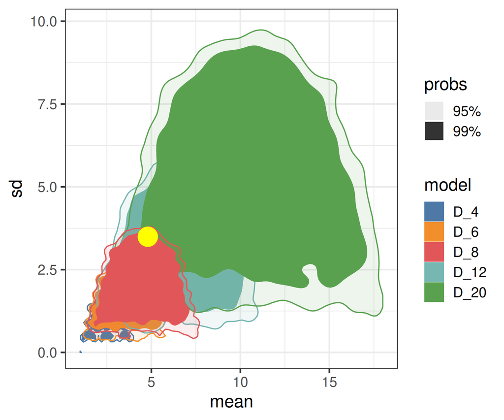

Can the selected model reproduce the observed summary statistics?

**Check your answer**

The yellow point lies in a region represented by simulations from the selected model. There is no obvious mismatch in this plot: the selected die can generate similar summaries.

That is reassuring, but it is not proof that we have found the true die.

Can you think of another statistic to describe the five rolls? If you have an idea, try adding it.

You would need to calculate it for both the observation and the simulations, then train a new forest. If the original rolls were not saved, you would need to simulate them again.

To simulate n rolls of a fair die with S sides, use:

```r
sample(1:S, size = n, replace = TRUE)
```

`replace = TRUE` allows the same face to appear more than once, just as it can when rolling a real die.

### A missing candidate: the D100

Now let us try to fool the forest.

We will generate five rolls from a D100, but ask the forest to choose among the same five candidates: D4, D6, D8, D12 and D20. This time, we know that the true die is missing.

As above, `sample()` simulates the rolls. We use `replace = TRUE` because a face can appear again on the next roll.

```r
set.seed(20260915)
```

```r
dice_observation_100 = sample(
  1:100,
  size = 5,
  replace = TRUE
)
```

Look at the five values we have just generated:

```r
dice_observation_100
```

```
[1]  7 81 63 82  7
```

Summarise this new observation using the same statistics as before: mean and sd.

Once trained, a forest can be reused for new observations, provided they are described by the same statistics and a comparable sampling design (five rolls in this example). Whether those observations are well represented by the training simulations is something we still need to check.

```r
dice_observed_ss_100 = tibble(
  mean = mean(dice_observation_100),
  sd = sd(dice_observation_100)
)
```

```r
set.seed(20260915)
```

```r
dice_prediction_100 = predict(
  dice_forest,
  obs = as.data.frame(dice_observed_ss_100),
  training = as.data.frame(dice_reference),
  ntree = 200,
  paral = FALSE,
  ncores = 1
)
```

What does our forest make of this new observation?

```r
dice_prediction_100
```

```
  selected model votes model1 votes model2 votes model3 votes model4 votes model5 post.proba
1           D_20            0            0            0            0          200          1
```

- Which candidate model is selected?
- Does the reported posterior probability make you confident in that answer?

In this run, the forest selects D20 with an estimated posterior probability of 1. That looks extremely reassuring!

If we did not know how the observation had been generated, we might be tempted to stop here. In a real demographic analysis, we do not know the true history either.

But here we know something the forest does not: these rolls came from a D100. Let us check whether D20 can actually reproduce what we observed.

Use the same plot as before, this time adding the summaries of the D100 rolls.

```r
dice_plot_100 = ggplot(
  dice_reference,
  aes(x = mean, y = sd, col = model, fill = model)
) +
  geom_hdr(probs = c(0.95, 0.99)) +
  geom_point(
    data = dice_observed_ss_100,
    aes(x = mean, y = sd),
    inherit.aes = FALSE,
    colour = "yellow",
    fill = "yellow",
    size = 7.5
  ) +
  xlim(range(c(dice_reference$mean, dice_observed_ss_100$mean))) +
  ylim(range(c(dice_reference$sd, dice_observed_ss_100$sd))) +
  scale_fill_tableau() +
  scale_color_tableau() +
  theme_bw(base_size = 15)
```

Display the new observation alongside the candidate models:

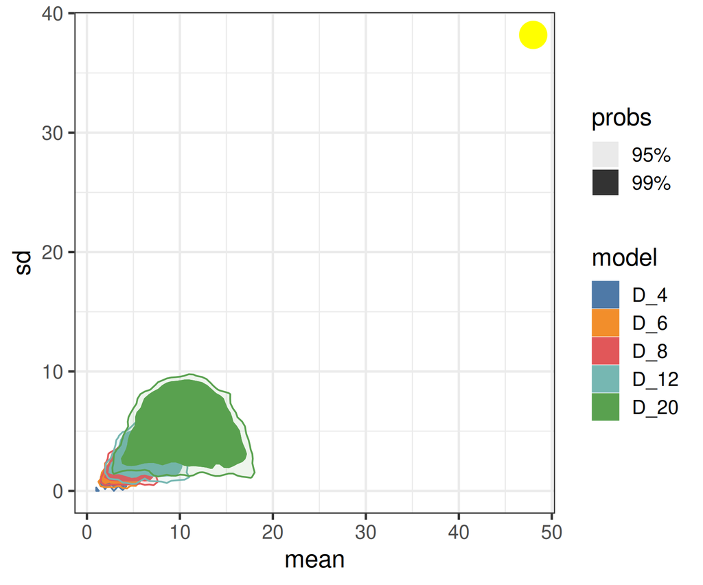

```r
print(dice_plot_100)
```

- Can the selected model reproduce the observation?
- Is the best available model necessarily a good model?
- Why did the forest report a probability of 1 for a model that is clearly wrong here?

**Check your answer**

The observation is far from the simulated candidates. D20 was selected, but it does not reproduce the observed pattern.

The forest was trained to choose among five dice. It has no ‘none of these’ answer, and it has never learned what a D100 looks like.

The reported probability is also estimated from those training simulations. Far outside the region they cover, that estimate can be misleading, even equal to 1. It is not a reliable statement that D20 must be the true die.

This is why model comparison and goodness of fit answer different questions. One chooses among the candidates; the other asks whether those candidates can reproduce the data.

You can keep experimenting with this example. What happens if you observe more rolls? Does the forest become better at recognising the die, and does support for the selected model increase?

To explore this, change the number of rolls in both the simulated training datasets and the observation, then train a new forest. You can also try adding other summary statistics, calculated in the same way for simulations and observations.

This flexibility is one of the strengths of the approach: you can change the models, the amount of data or the statistics, and explore what those choices allow you to learn.

We are now ready to replace dice with demographic histories.

The data will be more complex, but the questions remain familiar: which model is best supported, how much confidence should we place in that choice, and can the selected model reproduce what we observe?

## 1. Explore the data

Let us now turn to two mussel species: *Mytilus edulis* and *Mytilus galloprovincialis*.

We have genetic data from both species, but we do not know the history that produced them. Did they diverge without exchanging genes? Have they continued exchanging genes since their split? Or did they meet again after a period of isolation?

As with the dice, we will compare observations with simulations. Before training another forest, let us get to know the candidate histories and the data we will use to distinguish them.

### Four possible histories

The four scenarios below differ in when gene flow occurs. Follow each history from the past at the top towards the present at the bottom.

[figure not shown]

Four alternative demographic histories. Time runs from the past (top) to the present (bottom). Red lines represent gene genealogies; horizontal arrows indicate migration events. SI and AM end in isolation, whereas IM and SC include gene flow up to the present.

| Scenario | Name | History after the split |
| --- | --- | --- |
| SI | Strict isolation | No gene flow |
| AM | Ancient migration | Gene flow initially, followed by isolation |
| IM | Isolation with migration | Continuous gene flow |
| SC | Secondary contact | Isolation initially, followed by gene flow |

Rather than ask the forest to distinguish everything at once, we will break the problem into a series of questions.

First: is there ongoing gene flow?

For this comparison, IM and SC belong to the migration group because both include gene flow up to the present. SI and AM belong to the isolation group because neither includes ongoing gene flow.

The AM label deserves a moment of attention: these populations did exchange genes in the past. Here, isolation describes their present situation, not their entire history.

### Variation across the genome

A demographic history does not necessarily affect every part of the genome in the same way. Some regions may pass more easily between species, and the strength of genetic drift can also vary among regions.

We therefore consider variants of each scenario:

- 1N or 2N: effective population size is homogeneous or heterogeneous across loci.
- 1M or 2M: migration is homogeneous or heterogeneous across loci.

For example, `IM_2M_1N` combines continuous migration, variation in migration among loci, and homogeneous effective population size.

SI has no migration variant: there is no migration to make homogeneous or heterogeneous. Its two versions are `SI_1N` and `SI_2N`.

In the tables, you will find the words homogeneous and heterogeneous in the `genomic_Ne` and `genomic_migration` columns. The shorter labels 1N/2N and 1M/2M are used in the complete model names.

### Why use simulations?

For the dice, we could generate a new dataset with `sample()`. Simulating genetic data requires us to describe a demographic history, choose parameter values, and generate genetic variation under that history.

Writing these models for the simulator and producing the reference table takes more time. I have already done that part, so we can spend the workshop exploring the data and interpreting the inference.

Each simulation comes with a known model and known parameter values. These will be the examples from which our forests learn.

### Three tables

The files in `data/` separate three things: what we simulated, the parameter values used to simulate it, and what we observed in the mussels.

| File | Contents |
| --- | --- |
| `reference_summary_statistics.tsv` | Summary statistics for each simulated dataset, together with its model labels and identifiers |
| `observed_summary_statistics.tsv` | The same summary statistics calculated from the empirical dataset |
| `reference_parameters.tsv` | Parameter values used to generate each simulated dataset |

One row of the simulated summary-statistic table represents a complete multilocus dataset, summarised across loci. Think of it as one simulated version of our entire genetic dataset.

The observed table contains just one row, summarising the real data in the same way.

The parameter table tells us which values generated each simulation. We know these values for simulations; estimating them for the real data will come later.

### 1.1. Load the tables

Run the code from the `DILS/` directory, which contains `data/`, `R/` and `scripts/`.

We will continue using tidyverse to work with the tables. If you have just completed the dice exercise, it is already loaded; running this line again is harmless.

```r
library(tidyverse)
```

These files are tab-separated tables. `read_tsv()`, from tidyverse, reads them directly into tibbles.

Start with the simulated summary statistics:

```r
simulations_ss = read_tsv(
  "data/reference_summary_statistics.tsv",
  show_col_types = FALSE
)
```

Now read the same statistics calculated from the observed mussel data:

```r
observed_ss = read_tsv(
  "data/observed_summary_statistics.tsv",
  show_col_types = FALSE
)
```

Finally, read the parameter values used to generate the simulations:

```r
simulations_parameters = read_tsv(
  "data/reference_parameters.tsv",
  show_col_types = FALSE
)
```

Before looking at the contents, compare the sizes of the tables. Which two should have the same number of rows, and why?

`dim()` reports the number of rows followed by the number of columns.

```r
dim(simulations_ss)
```

```
[1] 70000    85
```

```r
dim(observed_ss)
```

```
[1]  1 77
```

```r
dim(simulations_parameters)
```

```
[1] 70000    24
```

**Check your answer**

The simulated statistics and simulation parameters describe the same collection of simulated datasets. They should therefore have the same number of rows.

The observed table has only one row because it describes our single empirical dataset, summarised across loci.

### 1.2. What do the columns represent?

The simulation table contains both genetic information and information about how each dataset was generated. We need to recognise the difference before using it to train a forest.

Look first at the eight metadata columns:

```r
names(simulations_ss)[1:8]
```

```
[1] "migration_status"  "genomic_migration" "genomic_Ne"        "scenario"          "model"             "simulation_id"     "batch"
[8] "row_in_batch"
```

The remaining columns contain the genetic summary statistics:

```r
names(simulations_ss)[9:ncol(simulations_ss)]
```

```
 [1] "bialsites_avg"   "bialsites_std"   "sf_avg"          "sf_std"          "sxA_avg"         "sxA_std"         "sxB_avg"         "sxB_std"
 [9] "ss_avg"          "ss_std"          "piA_avg"         "piA_std"         "piB_avg"         "piB_std"         "pearson_r_pi"    "thetaA_avg"
[17] "thetaA_std"      "thetaB_avg"      "thetaB_std"      "pearson_r_theta" "DtajA_avg"       "DtajA_std"       "DtajB_avg"       "DtajB_std"
[25] "divAB_avg"       "divAB_std"       "netdivAB_avg"    "netdivAB_std"    "FST_avg"         "FST_std"         "fA0_fB1"         "fA0_fB2"
[33] "fA0_fB3"         "fA0_fB4"         "fA0_fB5"         "fA0_fB6"         "fA1_fB0"         "fA1_fB1"         "fA1_fB2"         "fA1_fB3"
[41] "fA1_fB4"         "fA1_fB5"         "fA1_fB6"         "fA2_fB0"         "fA2_fB1"         "fA2_fB2"         "fA2_fB3"         "fA2_fB4"
[49] "fA2_fB5"         "fA2_fB6"         "fA3_fB0"         "fA3_fB1"         "fA3_fB2"         "fA3_fB3"         "fA3_fB4"         "fA3_fB5"
[57] "fA3_fB6"         "fA4_fB0"         "fA4_fB1"         "fA4_fB2"         "fA4_fB3"         "fA4_fB4"         "fA4_fB5"         "fA4_fB6"
[65] "fA5_fB0"         "fA5_fB1"         "fA5_fB2"         "fA5_fB3"         "fA5_fB4"         "fA5_fB5"         "fA5_fB6"         "fA6_fB0"
[73] "fA6_fB1"         "fA6_fB2"         "fA6_fB3"         "fA6_fB4"         "fA6_fB5"
```

| Metadata column | Meaning |
| --- | --- |
| `migration_status` | Ongoing migration or isolation |
| `genomic_migration` | Homogeneous or heterogeneous migration |
| `genomic_Ne` | Homogeneous or heterogeneous effective population size |
| `scenario` | SI, AM, IM or SC |
| `model` | Complete demographic and genomic model |
| `simulation_id` | Unique identifier for the simulation |
| `batch` | Simulation batch |
| `row_in_batch` | Simulation position within its batch |

Look at these labels for a few simulations. Can you describe the history represented by each row?

```r
simulations_ss %>%
  dplyr::select(1:8) %>%
  slice_head(n = 6)
```

```
# A tibble: 6 × 8
  migration_status genomic_migration genomic_Ne  scenario model    simulation_id      batch row_in_batch
  <chr>            <chr>             <chr>       <chr>    <chr>    <chr>              <dbl>        <dbl>
1 isolation        homogeneous       homogeneous AM       AM_1M_1N AM_1M_1N_00_000001     0            1
2 isolation        homogeneous       homogeneous AM       AM_1M_1N AM_1M_1N_00_000002     0            2
3 isolation        homogeneous       homogeneous AM       AM_1M_1N AM_1M_1N_00_000003     0            3
4 isolation        homogeneous       homogeneous AM       AM_1M_1N AM_1M_1N_00_000004     0            4
5 isolation        homogeneous       homogeneous AM       AM_1M_1N AM_1M_1N_00_000005     0            5
6 isolation        homogeneous       homogeneous AM       AM_1M_1N AM_1M_1N_00_000006     0            6
```

The model label is the answer we know for each simulation. The genetic statistics are the clues from which the forest must learn that answer.

### 1.3. How many simulations are available?

Let us see how the simulations are distributed among the models. We will use `count()`, just as we did for the dice: it groups rows by a column and counts how many belong to each group.

How many simulated datasets do we have altogether?

```r
nrow(simulations_ss)
```

```
[1] 70000
```

How many belong to migration and isolation, the two groups in our first comparison?

```r
simulations_ss %>%
  count(migration_status)
```

```
# A tibble: 2 × 2
  migration_status     n
  <chr>            <int>
1 isolation        30000
2 migration        40000
```

Now separate the four demographic scenarios. Do they all have the same number of simulations?

```r
simulations_ss %>%
  count(scenario)
```

```
# A tibble: 4 × 2
  scenario     n
  <chr>    <int>
1 AM       20000
2 IM       20000
3 SC       20000
4 SI       10000
```

Why does SI have fewer simulations than the other scenarios?

Look one level deeper, at the complete models. Is the number now the same for every model?

```r
simulations_ss %>%
  count(model)
```

```
# A tibble: 14 × 2
   model        n
   <chr>    <int>
 1 AM_1M_1N  5000
 2 AM_1M_2N  5000
 3 AM_2M_1N  5000
 4 AM_2M_2N  5000
 5 IM_1M_1N  5000
 6 IM_1M_2N  5000
 7 IM_2M_1N  5000
 8 IM_2M_2N  5000
 9 SC_1M_1N  5000
10 SC_1M_2N  5000
11 SC_2M_1N  5000
12 SC_2M_2N  5000
13 SI_1N     5000
14 SI_2N     5000
```

**Check your answer**

There are 70,000 simulations in total: 40,000 in migration and 30,000 in isolation.

Each complete model has 5,000 simulations. AM, IM and SC each have four genomic variants: two possibilities for Ne combined with two for migration. This gives 20,000 simulations per scenario.

SI has only its two Ne variants, giving 10,000 simulations.

The unequal numbers in migration and isolation therefore come from how the reference table was constructed. We have not yet used the observed mussel data, so these counts cannot tell us whether the species exchange genes.

### 1.4. How many summary statistics?

With the dice, we used only mean and sd. How many statistics describe each genetic dataset?

Let us store their names in a separate object. We will reuse this list when preparing the forests.

```r
summary_statistics = names(simulations_ss)[9:ncol(simulations_ss)]
```

`length()` tells us how many names are in this list:

```r
length(summary_statistics)
```

```
[1] 77
```

The observation must be described by the same statistics as the simulations. Check that their column names also appear in the same order:

```r
identical(
  summary_statistics,
  names(observed_ss)
)
```

```
[1] TRUE
```

**Check your answer**

There are 77 statistics: 30 conventional summary statistics and 47 cells of the joint site-frequency spectrum, or jSFS.

The comparison with the observed columns should return `TRUE`. This tells us that their names and order match, which is important when we compare simulated and observed statistics in the following analyses.

Some names may already be familiar. `piA_avg` describes average nucleotide diversity in population A, `DtajA_avg` refers to Tajima’s D, and `FST_avg` describes differentiation between the populations.

The suffixes `_avg` and `_std` mean that we calculated the mean and standard deviation across loci. This lets us describe both the typical value and how much it varies across the dataset.

The `fA…_fB…` columns describe the joint site-frequency spectrum. They count variants according to their allele counts in the two populations.

There is no need to memorise all 77 names. If one is unfamiliar, ask me: understanding what a statistic measures is much more useful than remembering its abbreviation. You can also consult `data/data_dictionary.tsv`.

### 1.5. Match simulations to their parameters

Every simulated dataset was generated with particular parameter values: population sizes, dates and, where relevant, migration rates.

We have stored the parameters and resulting genetic statistics in separate tables. Before using them together, we need to make sure that a row in one table corresponds to the same simulation in the other.

The tables were supplied in matching order. Check this using `simulation_id`:

```r
identical(
  simulations_ss$simulation_id,
  simulations_parameters$simulation_id
)
```

```
[1] TRUE
```

`TRUE` means that the identifiers match in the same order.

Have a look at the parameter names. We will return to their meanings when we estimate them:

```r
names(simulations_parameters)
```

```
 [1] "migration_status"  "genomic_migration" "genomic_Ne"        "scenario"          "model"             "simulation_id"     "batch"
 [8] "row_in_batch"      "N1"                "N2"                "Na"                "founders1"         "founders2"         "Tdem1"
[15] "Tdem2"             "shape_N_a"         "shape_N_b"         "Tsplit"            "Tam"               "Tsc"               "M12"
[22] "nBarriersM12"      "M21"               "nBarriersM21"
```

If you later sort or filter one table, remember that its row order may change. `simulation_id` gives us a way to reconnect each simulated dataset with the parameters that produced it.

### 1.6. Do different histories leave different signatures?

We now know how the reference table is organised. But do the competing histories actually produce different genetic patterns?

Let us look before asking a forest to classify them.

We will plot mean net divergence, Da, against mean FST. Each point represents one complete simulated dataset, and its colour tells us whether the history includes ongoing gene flow.

In `ggplot()`, `aes()` specifies which columns provide the coordinates and colours. `geom_point()` draws the simulations. The points are small and transparent because many will overlap.

```r
plot_div = ggplot(
  simulations_ss,
  aes(x = netdivAB_avg, y = FST_avg, colour = migration_status)
) +
  geom_point(alpha = 0.08, size = 0.5) +
  labs(
    title = "Net divergence and differentiation",
    subtitle = "Each point is one multilocus simulation",
    x = "Mean net divergence (Da)",
    y = "Mean FST",
    colour = "Ongoing gene flow"
  ) +
  theme_bw() +
  guides(
    colour = guide_legend(override.aes = list(alpha = 1, size = 2))
  )
```

The plot is stored in `plot_div`. Print it to see the result:

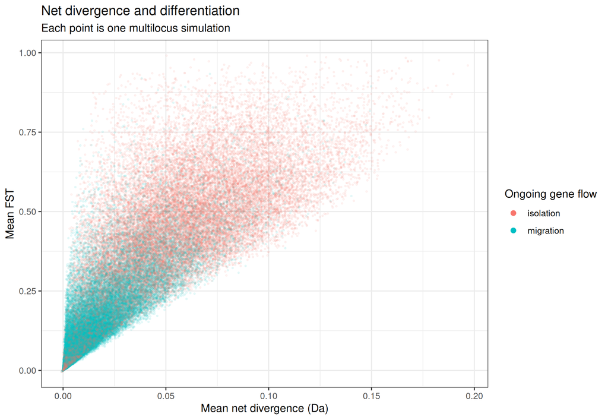

```r
print(plot_div)
```

Where do the two groups overlap? Could you confidently classify every point using these two statistics alone?

**Check your answer**

The colours are not distributed randomly across the plot: these statistics carry information about the demographic histories.

But the groups also overlap. A point in an overlapping region could have been generated with or without ongoing gene flow. That is where combining information from other statistics may help.

Try changing the plot yourself. Looking at the data from different angles is a useful way to understand what the forest will have to distinguish.

Here are three starting points.

First, colour the points by scenario instead of `migration_status`. Can you see which histories contribute to the overlap?

```r
plot_scenario = ggplot(
  simulations_ss,
  aes(x = netdivAB_avg, y = FST_avg, colour = scenario)
) +
  geom_point(alpha = 0.08, size = 0.5) +
  labs(
    x = "Mean net divergence (Da)",
    y = "Mean FST",
    colour = "Scenario"
  ) +
  theme_bw() +
  guides(
    colour = guide_legend(override.aes = list(alpha = 1, size = 2))
  )
```

```r
print(plot_scenario)
```

Next, compare average FST with its variation across loci. Two datasets can have a similar mean but differ in how unevenly differentiation is distributed across the genome.

```r
plot_fst = ggplot(
  simulations_ss,
  aes(x = FST_avg, y = FST_std, colour = migration_status)
) +
  geom_point(alpha = 0.08, size = 0.5) +
  labs(
    x = "Mean FST",
    y = "Standard deviation of FST",
    colour = "Ongoing gene flow"
  ) +
  theme_bw() +
  guides(
    colour = guide_legend(override.aes = list(alpha = 1, size = 2))
  )
```

```r
print(plot_fst)
```

Finally, compare homogeneous and heterogeneous migration within SC. We keep Ne homogeneous in both groups, so the comparison is easier to interpret.

The logarithmic x-axis shows positive net divergence values only.

```r
plot_mig_het = simulations_ss %>%
  dplyr::filter(
    scenario == "SC",
    genomic_Ne == "homogeneous",
    netdivAB_avg > 0
  ) %>%
  ggplot(
    aes(
      x = netdivAB_avg,
      y = FST_avg,
      colour = genomic_migration
    )
  ) +
  geom_point(alpha = 0.08, size = 0.5) +
  scale_x_log10(
    breaks = 10^seq(-5, -1),
    labels = c("0.00001", "0.0001", "0.001", "0.01", "0.1")
  ) +
  labs(
    x = "Mean net divergence (Da)",
    y = "Mean FST",
    colour = "Migration among loci"
  ) +
  theme_bw() +
  guides(
    colour = guide_legend(override.aes = list(alpha = 1, size = 2))
  )
```

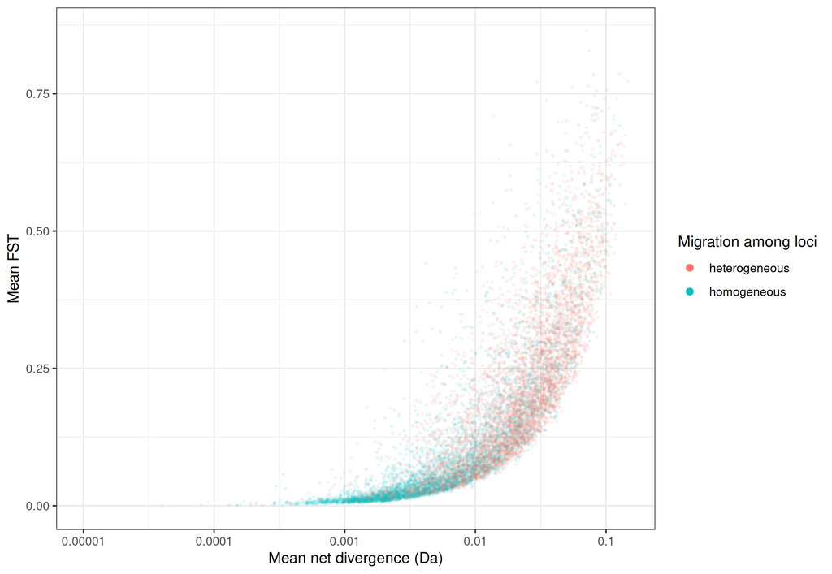

```r
print(plot_mig_het)
```

You can try other statistics too. Which combinations make the models easier to distinguish, and which leave most points mixed together?

### 1.7. Add the observation

So far, we have looked only at simulations. Where do the real mussel data fall?

Just as in the dice example, the observed dataset becomes one point, with coordinates given by the same two statistics.

We can reuse `plot_div` and add a new layer for the observation. The larger yellow point will be drawn on top of the simulations.

```r
plot_div_observed = plot_div +
  geom_point(
    data = observed_ss,
    aes(x = netdivAB_avg, y = FST_avg),
    inherit.aes = FALSE,
    shape = 21,
    fill = "yellow",
    colour = "black",
    size = 4,
    stroke = 1.2
  )
```

Print the updated plot:

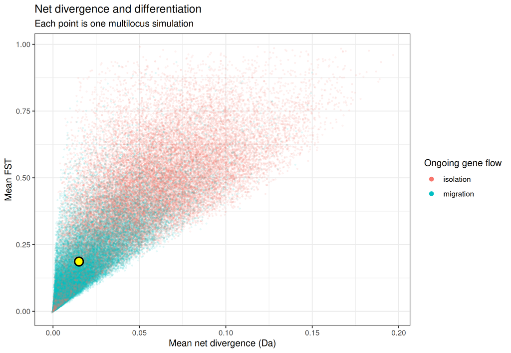

```r
print(plot_div_observed)
```

First ignore the colours: does the yellow point fall within the simulated cloud? Then look at the colours: which histories surround it?

**Check your answer**

Start with the first question, just as we did for the D100. If the observation lies far outside all the simulations, choosing a winner among them will not solve the mismatch. The models, their parameter priors, or both may need revisiting.

If the observation falls within the cloud, look more closely at the colours. Does one group dominate its neighbourhood, or could several histories generate similar values?

This plot gives us a first impression. It does not yet combine all the statistics or quantify support for a model.

We now have the ingredients for our first demographic comparison: simulations with known histories, genetic statistics describing each simulation, and an observation summarised in the same way.

The plots suggest where the histories differ and where they overlap. Let us now see what a random forest can learn from the full set of statistics.

## 2. Is there ongoing gene flow?

We are ready to ask our first biological question: do the genetic data support ongoing gene flow between the two mussel species?

Remember that two of our scenarios include gene flow up to the present, while the other two do not. For now, we group the histories according to this difference.

| Class | Scenarios | Ongoing gene flow |
| --- | --- | --- |
| isolation | SI, AM | No |
| migration | IM, SC | Yes |

This is the same task as recognising the dice. During training, the forest knows which group produced each simulated dataset. It learns which combinations of genetic statistics help distinguish the two groups.

We will first see how often it gets the simulations wrong. Then we will ask it to classify the observed mussel data.

### 2.1. Prepare the training table

We will use abcrf again. If you completed the dice example in this R session, the package is already loaded.

```r
library(abcrf)
```

Let us prepare a table containing the answer to learn (`migration_status`) and the 77 summary statistics from which to learn it.

As with the dice, the class label must be a factor. We set its levels to isolation and migration, in that order.

```r
dat = simulations_ss %>%
  dplyr::select(migration_status, all_of(summary_statistics)) %>%
  dplyr::mutate(
    migration_status = factor(
      migration_status,
      levels = c("isolation", "migration")
    )
  )
```

We will need to examine the statistics before training. Store their names in a separate vector: `setdiff()` keeps all the column names except `migration_status`.

```r
predictors = setdiff(names(dat), "migration_status")
```

### 2.2. Check variation before training

There is one extra preparation step compared with the dice.

By default, `abcrf` adds combinations of statistics calculated by linear discriminant analysis, or LDA. These combinations are designed to help separate the model groups. But the calculation can fail if a statistic has too little variation within the groups.

The important question is not simply whether a statistic varies across the whole table. It is whether variation remains after accounting for the difference between the two group means.

To check for this, we subtract the isolation mean from each isolation value and the migration mean from each migration value. We then calculate the standard deviation of all these remaining differences.

The code repeats that calculation for each statistic. `map_dbl()` runs the function once per predictor and collects one number each time. Inside the function, `ave()` supplies the appropriate group mean for every simulation.

```r
within_group_sd = map_dbl(predictors, function(v) {
  values = dat[[v]]
  groups = dat$migration_status

  residuals = values - ave(values, groups, FUN = mean)

  sd(residuals)
})
```

What did this calculation produce? Each statistic now has one value describing how much variation remains after subtracting the group means.

Let us plot these values in the same order as the columns in our table.

```r
variation_table = tibble(
  statistic = factor(predictors, levels = predictors),
  residual_sd = within_group_sd
)
```

```r
plot_residual_sd = ggplot(
  variation_table,
  aes(
    x = statistic,
    y = residual_sd,
    colour = residual_sd < 1e-4
  )
) +
  geom_point(size = 1.6) +
  geom_hline(yintercept = 1e-4, colour = "grey20", linewidth = 0.4) +
  scale_colour_manual(
    values = c("FALSE" = "#4D4D4D", "TRUE" = "#E67E22"),
    guide = "none"
  ) +
  scale_y_continuous(
    trans = scales::pseudo_log_trans(base = 10, sigma = 1e-4),
    breaks = c(0, 1e-4, 1e-3, 1e-2, 1e-1, 1, 10, 100, 1000, 10000),
    labels = c("0", "0.0001", "0.001", "0.01", "0.1", "1", "10", "100", "1000", "10000")
  ) +
  theme_bw() +
  theme(
    axis.text.x = element_text(angle = 90, vjust = 0.5, hjust = 1, size = 7)
  ) +
  labs(
    x = "Statistic",
    y = "Residual standard deviation"
  )
```

The vertical axis is compressed for larger values so that we can see both the zeros and the much larger standard deviations. The horizontal line marks the filtering threshold.

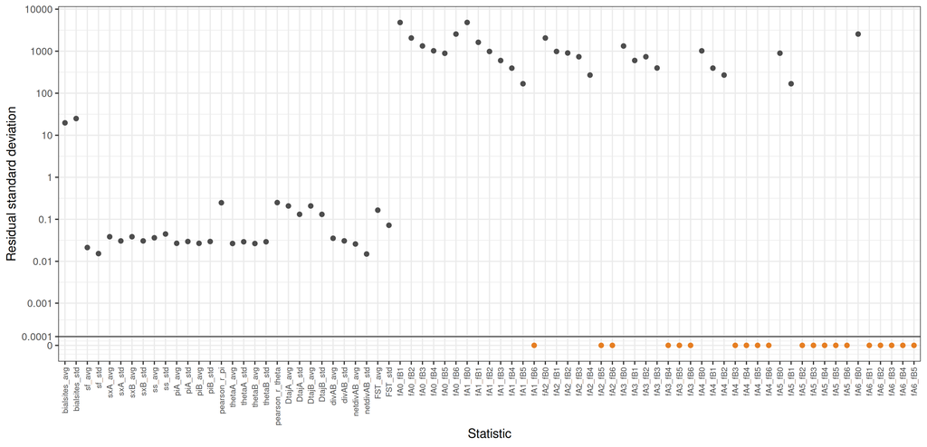

```r
print(plot_residual_sd)
```

Which statistics sit at zero? Are they scattered throughout the table, or do their names suggest something in common?

We now identify statistics whose remaining standard deviation is below 10^-4. The same line also catches non-finite results, although our input checks should already have ruled out missing or invalid values.

```r
dropped_statistics = predictors[
  !is.finite(within_group_sd) | within_group_sd < 1e-4
]
```

This is a numerical threshold for the residual standard deviation, not a ranking of biological importance. Its effect depends on the units in which a statistic is expressed.

Which statistics were picked up by this check? Look at their names:

```r
dropped_statistics
```

```
 [1] "fA1_fB6" "fA2_fB5" "fA2_fB6" "fA3_fB4" "fA3_fB5" "fA3_fB6" "fA4_fB3" "fA4_fB4" "fA4_fB5" "fA4_fB6" "fA5_fB2" "fA5_fB3" "fA5_fB4" "fA5_fB5"
[15] "fA5_fB6" "fA6_fB1" "fA6_fB2" "fA6_fB3" "fA6_fB4" "fA6_fB5"
```

The discarded statistics all belong to the joint site-frequency spectrum. Why are these particular cells empty?

For this dataset, we did not use an outgroup to identify the ancestral allele. We therefore use a folded spectrum: the two alleles at a site are oriented according to their combined counts across the two populations.

Here, the spectrum uses six allele copies per population. Folding places each site on the side where the combined count is at most six. Cells with `fA + fB > 6` are therefore empty by construction.

The pattern is easier to understand when we plot the spectrum in 2D. Below is the folded jSFS of the observed mussel dataset.

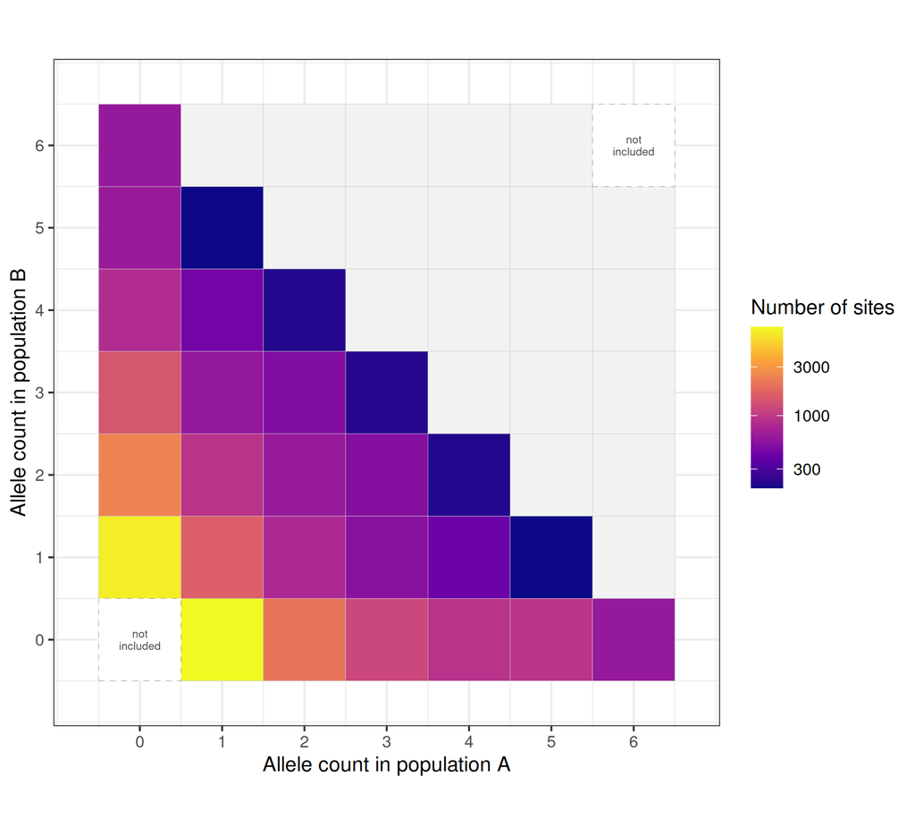

The colour scale is logarithmic because singletons are usually much more abundant than other categories. Grey cells contain zero sites.

Notice the empty triangle where the two allele counts sum to more than six. These structural zeros explain the columns identified by our variation check.

Remove these columns to obtain the table we will give to the forest. The minus sign in `select()` means that the named columns are excluded.

```r
dat_clean = dat %>%
  dplyr::select(-all_of(dropped_statistics))
```

How many statistics remain? `dat_clean` also contains the class label, so subtract one from its number of columns.

```r
ncol(dat_clean) - 1
```

```
[1] 57
```

**A detail about this check**

We calculate the remaining variation across both groups together. A statistic can therefore pass the check even if it is constant in one group, provided it varies enough in the other.

A statistic could equal 0 in every isolation simulation and 1 in every migration simulation. It would distinguish the groups perfectly, yet this filter would remove it because it has no variation within either group.

In that situation, it would be worth comparing two forests: one using the filtered table with LDA, and one using the full table with `lda = FALSE`. This is a useful limitation to keep in mind, although it is not what happens with the empty jSFS cells here.

### 2.3. Train the forest

Our training table is ready. We use the same seed as before so that results can be compared.

```r
set.seed(20260915)
```

This time, we will grow 500 trees. In the formula `migration_status ~ .`, the left-hand side is the class to predict, and the dot stands for every other column in `dat_clean`: the retained genetic statistics.

```r
model_mig_iso = abcrf(
  migration_status ~ .,
  data = as.data.frame(dat_clean),
  ntree = 500,
  paral = FALSE,
  ncores = 1
)
```

Explore the trained forest yourself. Printing the object gives us a first look at its performance:

```r
model_mig_iso
```

```
Call:
 abcrf(formula = migration_status ~ ., data = as.data.frame(dat_clean), ntree = 500, paral = FALSE, ncores = 1)
includes the axes of a preliminary LDA

Number of simulations: 70000
Out-of-bag prior error rate: 3.8529%

Confusion matrix:
          isolation migration class.error
isolation     28324      1676  0.05586667
migration      1021     38979  0.02552500
```

### 2.4. Interpret the confusion matrix

How often does the forest recognise the correct history?

We can answer this for simulations because we know their true class. As in the dice example, the out-of-bag predictions use trees that did not train on the simulation being classified.

Read a row of the confusion matrix to follow one true class. The diagonal entry counts correct classifications; the other entry counts mistakes.

1. What fraction of isolation simulations are classified as migration?
2. What fraction of migration simulations are classified as isolation?
3. Why might one class be easier to recognise than the other?
4. What could make this comparison easier or harder?

**Check your answer**

For the first two questions, read `class.error` and multiply by 100 to obtain percentages.

Now think about the simulations behind these errors. Two different histories can produce similar genetic data. For example, after a very recent split, populations can still share much of their ancestral variation even if they no longer exchange genes. Shared variation alone does not necessarily reveal ongoing migration.

The parameter priors therefore matter. They determine which versions of each history we ask the forest to distinguish: some will be very different, others much more similar.

The statistics also matter. A difference between models is only useful to the classifier if the statistics capture it. The amount of genetic data and the number of training simulations can affect performance too.

A low error is encouraging, but making the simulated models easy to distinguish is not our only goal. The models and parameter ranges must also be biologically relevant to the data we want to explain.

These errors concern the simulated datasets. We still need to estimate support for a classification of the actual mussel data.

### 2.5. Predict the class of the observation

Let us now give the forest the real data.

It learned from the statistics in `dat_clean`, so the observation must contain those same predictors. We therefore select the retained columns from `observed_ss`, in the same order.

```r
observed_clean = observed_ss %>%
  dplyr::select(all_of(setdiff(names(dat_clean), "migration_status")))
```

We also set the seed for the probability-estimation step.

```r
set.seed(20260915)
```

The prediction call uses three ingredients: the trained forest, the observed statistics, and the reference table used during training.

```r
predicted_model_iso_mig = predict(
  model_mig_iso,
  obs = as.data.frame(observed_clean),
  training = as.data.frame(dat_clean),
  ntree = 500,
  paral = FALSE,
  ncores = 1
)
```

While this runs, remember the distinction from the dice example: the classification trees vote for a group, and an additional regression forest estimates the probability that the selected group is correct. The fraction of votes is not that posterior probability.

What does the forest conclude about the mussels?

```r
predicted_model_iso_mig
```

```
  selected model votes model1 votes model2 post.proba
1      migration            4          496     0.9846
```

- Does the forest select migration or isolation?
- What estimated posterior probability supports that choice?
- Does this agree with your impression from the plot of net divergence and FST?

**Check your answer**

The selected model column gives the chosen group. The two vote columns correspond to isolation and migration, respectively, because that is the order we gave the factor.

`post.proba` is the estimated posterior probability of the selected group.

Return to the yellow point in our earlier plot. Did it lead you to expect this result? The forest has used many more statistics than the two we displayed, so it can use information that was not visible in that plot.

If migration is selected, the data favour histories with ongoing gene flow over SI and AM. Among the models we proposed, that still leaves two possible histories: continuous migration under IM, or renewed migration after isolation under SC.

If isolation is selected, the next comparison would instead distinguish SI from AM.

Store the selected group so that we can use it in the next step. `allocation` contains the selected class; `[1]` takes the result for our single observed dataset.

```r
selected_migration_status = as.character(
  predicted_model_iso_mig$allocation[1]
)
```

Check which group has been stored:

```r
selected_migration_status
```

```
[1] "migration"
```

In the following section, we will follow the migration branch and ask when gene flow occurred.

## 3. When did gene flow occur?

Our first comparison supports ongoing gene flow. But that result does not tell us whether the species have exchanged genes throughout their divergence or only after meeting again.

Among our candidate models, these possibilities are represented by IM and SC:

- IM: migration has continued since the populations split.
- SC: populations first evolved in isolation, then came into contact and resumed exchanging genes.

We will now ask the forest to distinguish these two histories.

We keep only the simulations from the migration group. The answer to learn is now `scenario`, with two possible values: IM and SC.

```r
dat_scenario = simulations_ss %>%
  dplyr::filter(migration_status == "migration") %>%
  dplyr::select(scenario, all_of(summary_statistics)) %>%
  dplyr::mutate(
    scenario = factor(scenario, levels = c("IM", "SC"))
  )
```

How many examples of each history will the forest learn from?

```r
dat_scenario %>%
  dplyr::count(scenario)
```

```
# A tibble: 2 × 2
  scenario     n
  <fct>    <int>
1 IM       20000
2 SC       20000
```

For now, we keep all genomic variants within each scenario. Both IM and SC therefore include simulations with homogeneous or heterogeneous Ne and migration.

We have changed the training data and the groups being compared. A statistic that varied before may no longer vary within these groups, so we repeat the preparation from the previous section.

First, separate the statistic names from the scenario label.

```r
predictors_scenario = setdiff(names(dat_scenario), "scenario")
```

Calculate the variation remaining after subtracting the IM or SC mean.

```r
within_group_sd_scenario = map_dbl(predictors_scenario, function(v) {
  values = dat_scenario[[v]]
  groups = dat_scenario$scenario

  residuals = values - ave(values, groups, FUN = mean)

  sd(residuals)
})
```

Apply the same numerical threshold as before.

```r
dropped_statistics_scenario = predictors_scenario[
  !is.finite(within_group_sd_scenario) | within_group_sd_scenario < 1e-4
]
```

Are the excluded statistics the same as in our first comparison?

```r
dropped_statistics_scenario
```

```
 [1] "fA1_fB6" "fA2_fB5" "fA2_fB6" "fA3_fB4" "fA3_fB5" "fA3_fB6" "fA4_fB3" "fA4_fB4" "fA4_fB5" "fA4_fB6" "fA5_fB2" "fA5_fB3" "fA5_fB4" "fA5_fB5"
[15] "fA5_fB6" "fA6_fB1" "fA6_fB2" "fA6_fB3" "fA6_fB4" "fA6_fB5"
```

Remove these columns to prepare the training table.

```r
dat_scenario_clean = dat_scenario %>%
  dplyr::select(-all_of(dropped_statistics_scenario))
```

We can now train the forest. The procedure is unchanged; only the question and the simulations have changed.

```r
set.seed(20260915)
```

```r
model_scenario = abcrf(
  scenario ~ .,
  data = as.data.frame(dat_scenario_clean),
  ntree = 500,
  paral = FALSE,
  ncores = 1
)
```

Before looking at the mussels, see how well the forest recognises the simulated histories:

```r
model_scenario
```

```
Call:
 abcrf(formula = scenario ~ ., data = as.data.frame(dat_scenario_clean), ntree = 500, paral = FALSE, ncores = 1)
includes the axes of a preliminary LDA

Number of simulations: 40000
Out-of-bag prior error rate: 15.7%

Confusion matrix:
      IM    SC class.error
IM 17168  2832      0.1416
SC  3448 16552      0.1724
```

- How often are IM simulations classified as SC, and vice versa?
- Is this comparison easier or harder than migration versus isolation?
- Why might the genetic signatures of IM and SC overlap?

**Check your answer**

The OOB error is higher here: distinguishing the timing of gene flow is harder than recognising ongoing gene flow in our reference table.

To see why, imagine shortening the initial isolation period in SC. As that period approaches zero, the history becomes increasingly similar to IM.

The names describe distinct scenarios, but some parameter combinations generate very similar data. Whether we can distinguish them depends on the parameter ranges and the information captured by our statistics.

Now describe the observed data using exactly the statistics retained for this comparison.

```r
observed_scenario = observed_ss %>%
  dplyr::select(all_of(setdiff(names(dat_scenario_clean), "scenario")))
```

We will use this forest to compare IM and SC for the mussels.

```r
set.seed(20260915)
```

```r
prediction_scenario = predict(
  model_scenario,
  obs = as.data.frame(observed_scenario),
  training = as.data.frame(dat_scenario_clean),
  ntree = 500,
  paral = FALSE,
  ncores = 1
)
```

Which history receives more support?

```r
prediction_scenario
```

```
  selected model votes model1 votes model2 post.proba
1             SC          176          324     0.9037
```

- Which scenario is selected?
- What is its estimated posterior probability?
- What does that scenario imply about the period between the split and the present?

**Check your answer**

The selected model gives the preferred history in this comparison; `post.proba` gives its estimated support. The vote columns correspond to IM, then SC.

Support for SC means that, among these alternatives, the data favour an initial period of isolation followed by renewed gene flow. It does not identify the geographic events that separated the populations or brought them together.

What could bring previously isolated populations back into contact?

**Check your answer**

Think of species ranges moving as the climate changes. Populations may become separated in different refuges and diverge there. Later expansion can bring them together again, creating opportunities for hybridisation and renewed gene flow.

Hewitt’s reviews describe how repeated climatic changes produced such patterns in many organisms. They give us a biological picture of secondary contact, rather than a demonstration of the particular events experienced by these mussels.

Hewitt, G. M. (2000). The genetic legacy of the Quaternary ice ages. *Nature*, 405, 907–913.

Hewitt, G. M. (2004). Genetic consequences of climatic oscillations in the Quaternary. *Philosophical Transactions of the Royal Society B*, 359, 183–195. https://doi.org/10.1098/rstb.2003.1388

Keep the selected scenario: the next comparisons will use simulations from this history.

```r
selected_scenario = as.character(prediction_scenario$allocation[1])
```

Check the value stored in `selected_scenario`:

```r
selected_scenario
```

```
[1] "SC"
```

From now on, we will work within the selected SC scenario. We will ask whether effective population size varies across the genome, and whether migration does too.

## 4. Does effective population size vary across the genome?

We have chosen a demographic scenario. But does one effective population size adequately describe every region of the genome?

The individuals belong to the same populations, yet different genomic regions can have different genealogical histories. In particular, selection can reduce genetic diversity around some loci more strongly than others. Allowing local Ne to vary is one way to represent such differences in our simulations.

We will compare:

- 1N: effective population size is homogeneous across loci within each population.
- 2N: effective population size varies among loci.

In the table, these alternatives are labelled `homogeneous` and `heterogeneous` in `genomic_Ne`.

Keep the selected scenario and make `genomic_Ne` the class to predict.

```r
dat_Ne = simulations_ss %>%
  dplyr::filter(scenario == selected_scenario) %>%
  dplyr::select(genomic_Ne, all_of(summary_statistics)) %>%
  dplyr::mutate(
    genomic_Ne = factor(
      genomic_Ne,
      levels = c("homogeneous", "heterogeneous")
    )
  )
```

How many simulations represent each alternative?

```r
dat_Ne %>%
  dplyr::count(genomic_Ne)
```

```
# A tibble: 2 × 2
  genomic_Ne        n
  <fct>         <int>
1 homogeneous   10000
2 heterogeneous 10000
```

We keep both migration variants within each Ne class. This lets us compare 1N and 2N without first deciding whether migration itself is homogeneous.

The preparation should now look familiar. List the statistics, check their variation within the new groups, and remove the columns that cannot be used by the LDA.

Store the predictor names.

```r
predictors_Ne = setdiff(names(dat_Ne), "genomic_Ne")
```

Calculate the remaining variation within the Ne classes.

```r
within_group_sd_Ne = map_dbl(predictors_Ne, function(v) {
  values = dat_Ne[[v]]
  groups = dat_Ne$genomic_Ne

  residuals = values - ave(values, groups, FUN = mean)

  sd(residuals)
})
```

Identify the statistics below the threshold.

```r
dropped_statistics_Ne = predictors_Ne[
  !is.finite(within_group_sd_Ne) | within_group_sd_Ne < 1e-4
]
```

Look at the names before removing them.

```r
dropped_statistics_Ne
```

```
 [1] "fA1_fB6" "fA2_fB5" "fA2_fB6" "fA3_fB4" "fA3_fB5" "fA3_fB6" "fA4_fB3" "fA4_fB4" "fA4_fB5" "fA4_fB6" "fA5_fB2" "fA5_fB3" "fA5_fB4" "fA5_fB5"
[15] "fA5_fB6" "fA6_fB1" "fA6_fB2" "fA6_fB3" "fA6_fB4" "fA6_fB5"
```

Prepare the filtered training table.

```r
dat_Ne_clean = dat_Ne %>%
  dplyr::select(-all_of(dropped_statistics_Ne))
```

Train the forest to recognise the two Ne models from their genetic summaries.

```r
set.seed(20260915)
```

```r
model_Ne = abcrf(
  genomic_Ne ~ .,
  data = as.data.frame(dat_Ne_clean),
  ntree = 500,
  paral = FALSE,
  ncores = 1
)
```

How well does it recognise them in the simulations?

```r
model_Ne
```

```
Call:
 abcrf(formula = genomic_Ne ~ ., data = as.data.frame(dat_Ne_clean), ntree = 500, paral = FALSE, ncores = 1)
includes the axes of a preliminary LDA

Number of simulations: 20000
Out-of-bag prior error rate: 12.09%

Confusion matrix:
              homogeneous heterogeneous class.error
homogeneous          9269           731      0.0731
heterogeneous        1687          8313      0.1687
```

- Which class is more often misclassified?
- Does the forest distinguish these models more easily than IM and SC?

**Check your answer**

Use the confusion matrix to compare the errors for homogeneous and heterogeneous Ne, then compare the overall OOB error with the previous forest.

These comparisons differ in both the biological question and the simulations included. Their errors tell us about the difficulty of each task under this simulation design.

Select the same retained statistics from the observed dataset.

```r
observed_Ne = observed_ss %>%
  dplyr::select(all_of(setdiff(names(dat_Ne_clean), "genomic_Ne")))
```

Now ask which Ne model better explains the mussel data.

```r
set.seed(20260915)
```

```r
prediction_Ne = predict(
  model_Ne,
  obs = as.data.frame(observed_Ne),
  training = as.data.frame(dat_Ne_clean),
  ntree = 500,
  paral = FALSE,
  ncores = 1
)
```

Read the selected class and its estimated support:

```r
prediction_Ne
```

```
  selected model votes model1 votes model2 post.proba
1  heterogeneous            6          494     0.9888
```

- Does the forest favour homogeneous or heterogeneous Ne?
- How strong is the estimated support?
- If Ne varies across loci, what biological processes might produce that pattern?

**Check your answer**

Selection at one site can affect variation at nearby sites because linked variants are inherited together.

With background selection, deleterious alleles are removed, along with some of the neutral variation associated with them.

With a selective sweep, a beneficial allele spreads and carries nearby variants with it. This can also reduce local diversity.

Both processes can leave patterns that we represent here using variation in local Ne. Selecting 2N supports that variation within our model comparison, but does not tell us which process caused it.

Could comparing the same genomic regions between species help us go further?

**Check your answer**

Suppose the two species have similar recombination landscapes and similar distributions of selected sites. Background selection could then reduce diversity in corresponding regions of both genomes, particularly where recombination is low.

A sweep specific to one lineage could instead produce a reduction in only that species.

This suggests an idea for another model comparison: allow reductions in local Ne to be correlated between species, or let them vary independently. Would those models produce distinguishable genetic patterns?

The distinction would not be perfect. Sweeps also depend on recombination and may affect the same regions in different species. Recombination maps and other signatures of selection would help us interpret the result.

Store the selected Ne class. We will combine it with the other choices once we have examined migration across the genome.

```r
selected_genomic_Ne = as.character(prediction_Ne$allocation[1])
```

Check which class has been stored:

```r
selected_genomic_Ne
```

```
[1] "heterogeneous"
```

Our next question concerns migration: is it equally permissive across loci, or do some regions resist gene flow more strongly than others?

## 5. Does migration vary across the genome?

We have examined variation in effective population size. Let us now ask whether gene flow is equally permissive across the genome.

If two species hybridise, some genomic regions may pass between them more easily than others. Regions associated with reproductive barriers may resist that exchange.

Our simulations represent this contrast using two alternatives:

- 1M: the migration rate is the same across loci within each direction.
- 2M: some loci have non-zero migration, while others have a migration rate of zero.

This is a simplified picture of barriers, whose strength can vary in reality. In our 2M model, a locus can also be a barrier in one direction without being a barrier in the other.

The table labels these alternatives `homogeneous` and `heterogeneous` in `genomic_migration`.

Keep the SC simulations and make `genomic_migration` the class to predict.

```r
dat_migration = simulations_ss %>%
  dplyr::filter(scenario == selected_scenario) %>%
  dplyr::select(genomic_migration, all_of(summary_statistics)) %>%
  dplyr::mutate(
    genomic_migration = factor(
      genomic_migration,
      levels = c("homogeneous", "heterogeneous")
    )
  )
```

How many simulations represent each migration model?

```r
dat_migration %>%
  dplyr::count(genomic_migration)
```

We keep both Ne variants within each migration class. The previous comparison examined Ne while keeping both migration variants; here, we do the reverse. Both comparisons take place within the selected demographic scenario.

Prepare this comparison as before: list the statistics, check their variation within the two classes, and remove the columns that cannot be used by the LDA.

Store the statistic names.

```r
predictors_migration = setdiff(names(dat_migration), "genomic_migration")
```

Calculate the variation remaining after subtracting the class means.

```r
within_group_sd_migration = map_dbl(predictors_migration, function(v) {
  values = dat_migration[[v]]
  groups = dat_migration$genomic_migration

  residuals = values - ave(values, groups, FUN = mean)

  sd(residuals)
})
```

Identify the statistics below the threshold.

```r
dropped_statistics_migration = predictors_migration[
  !is.finite(within_group_sd_migration) | within_group_sd_migration < 1e-4
]
```

Look at their names.

```r
dropped_statistics_migration
```

Remove these columns from the training table.

```r
dat_migration_clean = dat_migration %>%
  dplyr::select(-all_of(dropped_statistics_migration))
```

We can now train the forest to distinguish homogeneous from heterogeneous migration.

```r
set.seed(20260915)
```

```r
model_migration = abcrf(
  genomic_migration ~ .,
  data = as.data.frame(dat_migration_clean),
  ntree = 500,
  paral = FALSE,
  ncores = 1
)
```

Before classifying the mussels, see how often the forest confuses the two simulated alternatives:

```r
model_migration
```

- What fraction of homogeneous simulations are classified as heterogeneous?
- What fraction of heterogeneous simulations are classified as homogeneous?
- Under what conditions might a heterogeneous migration model resemble a homogeneous one?

**Check your answer**

Read `class.error` for each true class.

Imagine a 2M simulation with very few barrier loci. Its overall genetic pattern could resemble a 1M simulation. If migration is weak throughout the genome, the difference between weak migration and zero migration at some loci may also be difficult to detect.

The forest can only recognise differences that leave a signal in the statistics we provide.

Give the observation the same set of statistics retained for this comparison.

```r
observed_migration = observed_ss %>%
  dplyr::select(all_of(setdiff(names(dat_migration_clean), "genomic_migration")))
```

Now apply the forest to the observed mussel data.

```r
set.seed(20260915)
```

```r
prediction_migration = predict(
  model_migration,
  obs = as.data.frame(observed_migration),
  training = as.data.frame(dat_migration_clean),
  ntree = 500,
  paral = FALSE,
  ncores = 1
)
```

Which migration model receives more support?

```r
prediction_migration
```

- Is migration inferred to be homogeneous or heterogeneous?
- What estimated posterior probability supports that choice?
- Is this result surprising after a period of isolation?

**Check your answer**

The selected model tells us which alternative is preferred; `post.proba` gives its estimated support.

Heterogeneous migration is biologically plausible after isolation. While populations are separated, they may accumulate genetic incompatibilities or adapt to different environments. When they meet again, some genomic regions may then cross the species boundary less easily than others.

This is one possible explanation for the result. The comparison does not establish when the barriers arose or what caused them.

We have not yet identified which loci resist gene flow. We will return to that question at the end of the workshop.

Keep the selected migration class so that we can combine our choices.

```r
selected_genomic_migration = as.character(
  prediction_migration$allocation[1]
)
```

Check the stored value:

```r
selected_genomic_migration
```

## 6. Putting the model choices together

Let us pause and put the answers together. We asked about ongoing gene flow, its timing, variation in Ne and variation in migration.

Which combination of these choices best describes the history supported for *Mytilus edulis* and *Mytilus galloprovincialis*?

**Check your answer**

Our comparisons support `SC_2M_2N`: secondary contact, heterogeneous migration and heterogeneous effective population size.

In biological terms, the populations first evolved in isolation and later resumed exchanging genes. The model also allows genomic regions to differ in their effective population sizes and permeability to gene flow.

The name records those choices in a fixed order: scenario, migration model, then Ne model. Build it from the results we stored:

```r
selected_complete_model = paste(
  selected_scenario,
  ifelse(selected_genomic_migration == "heterogeneous", "2M", "1M"),
  ifelse(selected_genomic_Ne == "heterogeneous", "2N", "1N"),
  sep = "_"
)
```

Does the assembled name match your answer?

```r
selected_complete_model
```

This name brings together several successive comparisons. We did not ask a single forest to compare all 14 complete models, so the separate probabilities should not be multiplied to obtain a probability for `SC_2M_2N`.

We now have a model to investigate further. How large were the populations? When did they split, and when did contact resume?

## 7. Estimating effective population size

So far, each forest has answered a question about a category: migration or isolation, IM or SC, homogeneous or heterogeneous.

We now want a number.

Let us start with `N1`, the effective population size of population 1, *Mytilus galloprovincialis*. Effective size describes the strength of genetic drift; it is not simply the number of mussels we could count in the population.

Under our 2N model, `N1` is the population’s reference size, while local effective sizes can differ among loci.

### Select the simulations of the retained model

We will use only simulations from the selected complete model. First, retrieve the parameter values used to generate them.

```r
best_model_param = simulations_parameters %>%
  dplyr::filter(model == selected_complete_model) %>%
  dplyr::select(
    -dplyr::all_of(c(
      "migration_status", "genomic_migration", "genomic_Ne",
      "scenario", "model", "batch", "row_in_batch"
    ))
  )
```

Retrieve the genetic summaries of those same simulations.

```r
best_model_ss = simulations_ss %>%
  dplyr::filter(model == selected_complete_model) %>%
  dplyr::select(simulation_id, dplyr::all_of(summary_statistics))
```

Remember the two tables we explored at the start? One contains the known parameter values, the other the genetic patterns they produced.

To learn their relationship, we must pair each simulation with its own parameters. Check the identifiers before joining the tables.

```r
setequal(
  best_model_param$simulation_id,
  best_model_ss$simulation_id
)
```

`left_join()` matches the rows using `simulation_id`:

```r
best_model_all = dplyr::left_join(
  best_model_param,
  best_model_ss,
  by = "simulation_id"
)
```

Did the join preserve one row per simulation?

```r
nrow(best_model_all) == nrow(best_model_param)
```

### Remove constant statistics

We again remove statistics that are constant in this set of simulations. They cannot help distinguish parameter values.

This time we will use `regAbcrf()`, which does not add a preliminary LDA. We therefore remove only statistics with zero variance.

Identify the summary-statistic columns.

```r
ss_cols = setdiff(names(best_model_ss), "simulation_id")
```

Calculate their variances.

```r
ss_variances = vapply(
  best_model_all[ss_cols],
  var,
  numeric(1)
)
```

Find those whose variance is zero.

```r
ss_to_remove = names(ss_variances)[ss_variances == 0]
```

Look at their names.

```r
ss_to_remove
```

Keep the remaining statistic names for the regression.

```r
retained_ss = setdiff(ss_cols, ss_to_remove)
```

### Build the regression table

The answer to learn is now the simulated value of `N1`. The clues are still the genetic statistics.

The other simulated parameters do not belong among the predictors: we will not know their true values when analysing the observation.

Make a table containing `N1` and the retained statistics.

```r
training_N1 = best_model_all %>%
  dplyr::select(N1, dplyr::all_of(retained_ss))
```

Describe the observation using those same statistics.

```r
observed_N1 = observed_ss %>%
  dplyr::select(dplyr::all_of(retained_ss))
```

### Train a regression forest

Instead of a classification forest, we now train a regression forest. The formula `N1 ~ .` asks it to predict a numerical `N1` value from the other columns.

```r
set.seed(20260915)
```

```r
model_N1 = regAbcrf(
  N1 ~ .,
  data = as.data.frame(training_N1),
  ntree = 500,
  paral = FALSE,
  ncores = 1
)
```

Look at the fitted regression object:

```r
model_N1
```

### Where does the forest estimate N1 well?

Before trusting an estimate for the mussels, let us see how well the forest estimates values that we already know.

For each simulation, compare its true `N1` with its OOB prediction. As before, that prediction comes from trees that did not train on that simulation.

Put the simulated and predicted values side by side.

```r
N1_oob = tibble(
  simulated = training_N1$N1,
  predicted = as.numeric(model_N1$model.rf$predictions)
)
```

Plot the true value on the horizontal axis and the prediction on the vertical axis. The diagonal marks a perfect prediction.

```r
plot_N1_oob = ggplot(
  N1_oob,
  aes(x = simulated, y = predicted)
) +
  geom_point(alpha = 0.3) +
  geom_abline(
    intercept = 0,
    slope = 1,
    linetype = 2,
    colour = "red"
  ) +
  coord_equal() +
  theme_bw() +
  labs(
    x = "N1 simulated",
    y = "N1 predicted (OOB)"
  )
```

Print the plot and look for where the predictions work well or poorly:

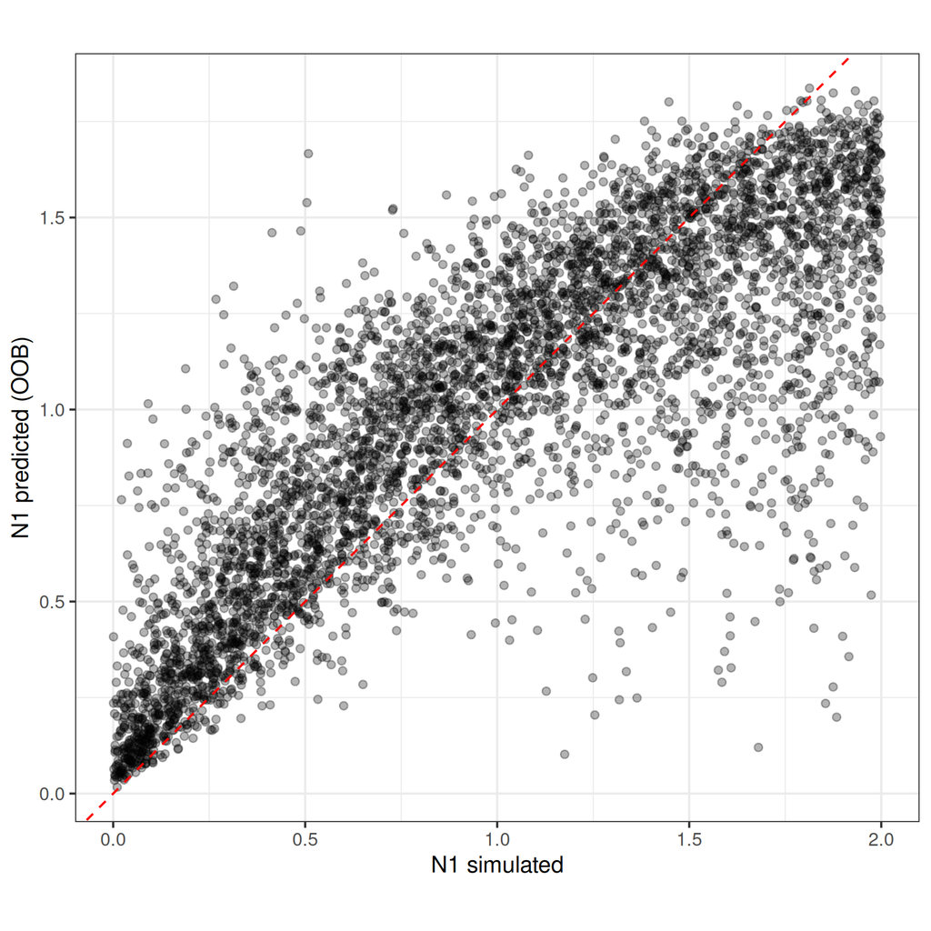

```r
print(plot_N1_oob)
```

- What would perfect predictions look like?
- Where are the predictions most dispersed?
- Are large N1 values systematically overestimated or underestimated?

**Check your answer**

If every prediction were exact, all points would fall on the diagonal.

The overall relationship shows that the statistics contain information about `N1`. But the scatter tells us that similar genetic patterns can correspond to different parameter values.

Here, the larger values tend to be underestimated. Regression trees average values within their leaves, which can pull predictions towards intermediate values, especially near the edges of the simulated range.

That is useful to know before interpreting the observed estimate. The forest captures a signal, but it does not recover every simulated parameter value precisely.

### Estimate N1 for the observation

We can now use the observed genetic statistics to estimate `N1` for the mussels.

```r
set.seed(20260915)
```

```r
estimate_N1 = predict(
  model_N1,
  obs = as.data.frame(observed_N1),
  training = as.data.frame(training_N1),
  quantiles = c(0.025, 0.975),
  paral = FALSE,
  ncores = 1
)
```

This output contains more than one number. Look at both the estimated value and the uncertainty around it.

```r
estimate_N1
```

How can the forest give us a median and an interval, rather than just one prediction? Each simulation comes with a known `N1`. The forest gives these simulated values different weights according to how their summary statistics compare with the observation. These weights provide an approximation of the posterior distribution, from which we can estimate its median and quantiles.

- What is the estimated posterior mean of N1?
- What range is covered by the 2.5% and 97.5% posterior quantiles?
- Does the estimate appear precise?

**Check your answer**

`expectation` is the estimated posterior mean. The median is another way to describe the centre of the estimated distribution.

The 2.5% and 97.5% quantiles give a central 95% credible interval. A narrow interval indicates a more precise estimate; a wide one means that substantial uncertainty remains under this model and these priors.

### Convert the units

An `N1` value around 1 does not mean a population of one mussel! Population sizes in these simulations are expressed relative to `Nref`, which was set to 500,000.

Multiply by `Nref` to express the estimates in individuals.

Store `Nref`.

```r
N_ref = 500000
```

Retrieve the two posterior quantiles.

```r
N1_quantiles = as.matrix(estimate_N1$quantiles)
```

Gather the mean, median and interval bounds in one table.

```r
N1_posterior_scaled = tibble(
  summary = c(
    "expectation (mean)",
    "median",
    "quantile_2.5%",
    "quantile_97.5%"
  ),
  scaled_N1 = c(
    as.numeric(estimate_N1$expectation),
    as.numeric(estimate_N1$med),
    as.numeric(N1_quantiles[, 1]),
    as.numeric(N1_quantiles[, 2])
  )
)
```

Convert the scaled values to individuals.

```r
N1_posterior = N1_posterior_scaled %>%
  dplyr::mutate(
    effective_population_size = scaled_N1 * N_ref
  )
```

Display rounded values so that the table is easier to read.

```r
N1_posterior %>%
  dplyr::mutate(
    scaled_N1 = round(scaled_N1, 3),
    effective_population_size = round(effective_population_size)
  )
```

```
# A tibble: 4 × 3
  summary            scaled_N1 effective_population_size
  <chr>                  <dbl>                     <dbl>
1 expectation (mean)     1.30                     648726
2 median                 1.29                     644089
3 quantile_2.5%          0.588                    293898
4 quantile_97.5%         1.94                     967332
```

Mean, median or expectation?

Mean and expectation are two names for the same quantity. There are therefore two different point estimates here, not three.

| Term | Meaning |
| --- | --- |
| Expectation / posterior mean | The average parameter value under the estimated posterior distribution. Values in a long tail can pull this average towards them. |
| Posterior median | The 50% posterior quantile: half of the posterior probability lies below this value and half above it. |
| 95% credible interval | The range between the 2.5% and 97.5% posterior quantiles, describing the remaining uncertainty. |

Which value should we report?

Both the mean and the median are valid summaries. They are usually close when the posterior distribution is roughly symmetric, but can differ when it is skewed.

In this workshop, report the posterior mean (expectation) together with the 95% credible interval. The interval matters: a single value does not show how uncertain the estimate remains.

Raynal et al. (2019). ABC random forests for Bayesian parameter inference. *Bioinformatics*, 35, 1720–1728. https://doi.org/10.1093/bioinformatics/bty867

Other parameters use other units. Times are multiplied by 4 × `Nref` to obtain generations. A conversion to years would also require a generation time.

We will keep track of these differences in the full parameter table below.

### Try another parameter

Your turn: choose another parameter and repeat the procedure.

Which parameters seem well estimated? For which ones does the forest struggle? Look at the OOB plot as well as the posterior interval.

The code below lists the parameters available under our selected model. If a name is unclear, ask me.

```r
parameter_columns = setdiff(names(best_model_param), "simulation_id")
defined_parameters = parameter_columns[
  vapply(
    parameter_columns,
    function(p) !all(is.na(best_model_param[[p]])),
    logical(1)
  )
]
```

```r
defined_parameters
```

You can also automate the procedure to explore several parameters. Each regression should contain just the parameter you want to estimate and the genetic statistics as predictors.

All these estimates assume the selected model. They do not include uncertainty about which demographic history is correct.

## Estimates for all parameters

The founder parameters are fractions of ancestral population size. To express the corresponding founder sizes in individuals, we calculate the product in each simulation and estimate that quantity directly. Multiplying separate posterior means would not give the same result.

We can repeat the same estimation for the other parameters. The table below summarises their posterior means, medians and 95% credible intervals.

| Parameter | Units | Mean (expectation) | Median | 2.5% | 97.5% |
| --- | --- | --- | --- | --- | --- |
| N1 | relative to Nref | 1.3 | 1.29 | 0.588 | 1.93 |
| N1 | individuals | 648726 | 644089 | 293898 | 967332 |
| N2 | relative to Nref | 0.915 | 0.786 | 0.371 | 1.85 |
| N2 | individuals | 457515 | 393125 | 185694 | 922865 |
| Na | relative to Nref | 0.641 | 0.658 | 0.27 | 0.946 |
| Na | individuals | 320410 | 329085 | 135080 | 472813 |
| founders1 | fraction of ancestral size | 0.458 | 0.451 | 0.0188 | 0.942 |
| founder_size_1 | individuals | 119379 | 113319 | 5241 | 293555 |
| founders2 | fraction of ancestral size | 0.563 | 0.559 | 0.0612 | 0.991 |
| founder_size_2 | individuals | 154631 | 158609 | 21241 | 288811 |
| Tdem1 | simulator units | 0.16 | 0.133 | 0.0096 | 0.424 |
| Tdem1 | generations | 320573 | 265032 | 19207 | 848734 |
| Tdem2 | simulator units | 0.134 | 0.0972 | 0.00407 | 0.452 |
| Tdem2 | generations | 267024 | 194371 | 8149 | 903688 |
| Tsplit | simulator units | 0.284 | 0.272 | 0.0919 | 0.624 |
| Tsplit | generations | 568807 | 543470 | 183724 | 1247112 |
| Tsc | simulator units | 0.0301 | 0.0246 | 0.00246 | 0.0835 |
| Tsc | generations | 60196 | 49254 | 4920 | 167019 |
| M12 | 4Nm | 17.6 | 16 | 2.88 | 38.9 |
| M21 | 4Nm | 21.6 | 21.5 | 2.66 | 38.7 |
| shape_N_a | dimensionless | 2.16 | 1.96 | 0.919 | 4.26 |
| shape_N_b | dimensionless | 3.15 | 3.59 | 0.272 | 4.89 |
| nBarriersM12 | loci | 430.7 | 416.0 | 28.8 | 869.0 |
| nBarriersM21 | loci | 434.3 | 417.4 | 76.5 | 850.0 |

Start by looking at the units and the widths of the intervals. Which parts of the history appear well constrained, and which remain uncertain?

Each row summarises one parameter. Combining every posterior mean into a single history does not necessarily give a combination that is jointly well supported.

Sizes are expressed in individuals and times in generations. Migration is reported as 4Nm; dividing by four gives Nm, the effective number of migrants per generation. Under 2M, this rate describes the loci that allow migration, while barrier loci have a rate of zero.

M12 describes migration from population B to A, and M21 from A to B.

The barrier parameters describe numbers of loci. Their posterior means can be non-integer, and they do not yet tell us which observed loci are candidates.

## 8. Can the selected model reproduce the data?

We now have a preferred model and estimates of its parameters. It would be tempting to stop here.

But remember our D100: the forest confidently selected a die that could not reproduce the observation.

Let us ask the same question about the mussels. Can the selected demographic model generate genetic data resembling what we observed?

### Read the goodness-of-fit table

I have already prepared simulations for this check. Read the table:

```r
gof = read.table(
  "data/goodness_of_fit_data.tsv",
  header = TRUE
) %>%
  tibble::as_tibble()
```

The `origin` column distinguishes simulations before parameter fitting, simulations after fitting, and the observation. How many rows belong to each?

```r
gof %>%
  dplyr::count(origin)
```

```
# A tibble: 3 × 2
  origin                   n
  <chr>                <int>
1 observed                 1
2 posterior_predictive 10000
3 prior_predictive     10000
```

| Origin | Meaning |
| --- | --- |
| prior_predictive | Simulations with parameter values drawn from the model’s prior distributions. |
| posterior_predictive | Simulations with parameter values drawn from the estimated posterior used in the original DILS analysis. |
| observed | Summary statistics calculated from the *Mytilus* data. |

These simulations were prepared before the workshop using the original DILS estimates. The posterior predictive simulations include uncertainty in the parameters: they do not all use one fixed set of posterior means.

Check that these simulations were generated under the same model we selected:

```r
unique(gof$fitted_model)
```

```
[1] "SC_2M_2N"
```

```r
identical(
  unique(as.character(gof$fitted_model)),
  selected_complete_model
)
```

```
[1] TRUE
```

If the model names differ, these simulations cannot answer the fit question for the model selected in your session.

### Examine one statistic

Start with something easy to picture: the average number of SNPs per locus.

We have one observed value. Does it look typical of what the model generates, or is it difficult to reproduce?

Keep simulations and observation in separate objects: the simulations define distributions, while the observation will be drawn as a line.

```r
gof_simulations = gof %>%
  dplyr::filter(origin != "observed") %>%
  dplyr::mutate(
    origin = factor(
      origin,
      levels = c("prior_predictive", "posterior_predictive")
    )
  )
```

```r
gof_observed = gof %>%
  dplyr::filter(origin == "observed")
```

Let us compare the simulated distributions of the mean number of SNPs per locus. The grey distribution represents the prior, the turquoise distribution the fitted model, and the black line the observation.

```r
plot_gof_univariate = ggplot(
  gof_simulations, aes(x = bialsites_avg, fill = origin)
) +
  geom_density(alpha = 0.4) +
  geom_vline(xintercept = gof_observed$bialsites_avg, linewidth = 1) +
  scale_fill_manual(
    values = c(prior_predictive = "grey70", posterior_predictive = "#40E0D0"),
    labels = c(prior_predictive = "Prior predictive",
               posterior_predictive = "Posterior predictive")
  ) +
  labs(x = "Mean number of SNPs per locus", y = "Density", fill = NULL) +
  theme_bw()
```

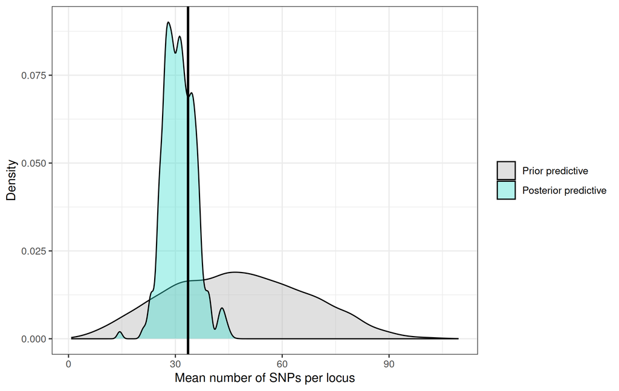

```r
print(plot_gof_univariate)
```

- Does the observation fall within the range represented by the prior simulations?
- Does parameter estimation bring the simulated distribution closer to the observation?
- Does the observation remain in an extreme tail of the posterior predictive distribution?

**Check your answer**

First compare the observation with the prior distribution. This shows whether the initial parameter ranges allowed the model to generate similar values.

Then look at the posterior predictive distribution. Did fitting the parameters bring the simulations closer to the observation?

If the observed value remains far in a tail, the fitted model struggles to reproduce this statistic. If it lies among common simulated values, there is no obvious mismatch for this statistic.

As with the dice, this is a visual check. It does not produce a p-value or establish that every feature of the data is reproduced.

### Try other statistics

Try another statistic, such as `piA_avg`, `piB_avg`, `netdivAB_avg` or `FST_avg`.

Replace `bialsites_avg` in both the density and the observation line, update the horizontal-axis label, and run the plot again. Does the fitted model reproduce all these statistics equally well?

## 9. Looking at the joint pattern

Looking at one statistic at a time is useful, but it leaves a question unanswered: can the model reproduce their combination?

A model might produce the observed diversity and the observed differentiation separately, yet rarely produce both together.

With the dice, we could show our two statistics in a single plot. Here we have many more. PCA gives us a way to summarise their joint variation in a few axes and locate the observation in that picture.

We will start from all 77 supplied statistics. PCA uses their numerical values, without using the prior/posterior labels to choose the axes.

Because the statistics use different units, we standardise them. Otherwise, large numerical counts could dominate simply because of their scale.

### Prepare the PCA

First, select the simulated statistics and check which ones are constant.

```r
gof_simulation_statistics = gof_simulations %>%
  dplyr::select(dplyr::all_of(summary_statistics))
```

```r
gof_simulation_sds = vapply(
  gof_simulation_statistics,
  sd,
  numeric(1)
)
```

```r
gof_constant_statistics = names(gof_simulation_sds)[
  !is.finite(gof_simulation_sds) | gof_simulation_sds == 0
]
```

```r
gof_constant_statistics
```

```
 [1] "fA1_fB6" "fA2_fB5" "fA2_fB6" "fA3_fB4" "fA3_fB5" "fA3_fB6" "fA4_fB3" "fA4_fB4" "fA4_fB5" "fA4_fB6" "fA5_fB2" "fA5_fB3" "fA5_fB4" "fA5_fB5"
[15] "fA5_fB6" "fA6_fB1" "fA6_fB2" "fA6_fB3" "fA6_fB4" "fA6_fB5"
```

Do you recognise these columns from our earlier filtering?

A constant statistic cannot be standardised for the PCA. But before removing it, check the observation: a value that differs from every simulation would itself reveal a mismatch.

Compare the observation with the constant simulated values:

```r
gof_machine_tolerance = sqrt(.Machine$double.eps)
gof_constant_mismatch = gof_constant_statistics[
  vapply(gof_constant_statistics, function(nm) {
    simulation_value = gof_simulation_statistics[[nm]][1]
    observed_value = gof_observed[[nm]]
    abs(observed_value - simulation_value) > gof_machine_tolerance
  }, logical(1))
]
```

Does any statistic differ?

```r
gof_constant_mismatch
```

```
character(0)
```

If a name appears here, the observation differs from every simulation for that statistic. That is already a mismatch worth investigating. We will leave constant statistics out of the PCA because they cannot be standardised, but we must keep this finding in our interpretation.

```r
gof_pca_statistics = setdiff(summary_statistics, gof_constant_statistics)
```

How many statistics remain?

```r
length(gof_pca_statistics)
```

```
[1] 57
```

Prepare the simulated values for the PCA.

```r
gof_simulation_predictors = gof_simulations %>%
  dplyr::select(dplyr::all_of(gof_pca_statistics))
```

Select the same columns, in the same order, for the observation.

```r
gof_observed_predictors = gof_observed %>%
  dplyr::select(dplyr::all_of(gof_pca_statistics))
```

### Fit and project

Fit the PCA using simulations only. This defines the centre, scaling and axes from the simulated data.

```r
gof_pca = prcomp(
  gof_simulation_predictors,
  center = TRUE,
  scale. = TRUE
)
```

Now project the observation onto those axes. It does not influence how the axes were constructed.

```r
gof_observed_coordinates = predict(
  gof_pca,
  newdata = gof_observed_predictors
)
```

PC1 captures the largest part of the variation among simulations. PC2 captures the largest remaining part along an axis perpendicular to PC1. The percentages on the axes tell us how much of the total variation this plot displays.

```r
gof_pca_variance = gof_pca$sdev^2 / sum(gof_pca$sdev^2)
```

Collect the coordinates returned for the simulations and the observation.

```r
gof_pca_simulations = tibble(
  origin = gof_simulations$origin,
  PC1 = gof_pca$x[, 1],
  PC2 = gof_pca$x[, 2]
)
```

```r
gof_pca_observed = tibble(
  PC1 = gof_observed_coordinates[1, "PC1"],
  PC2 = gof_observed_coordinates[1, "PC2"]
)
```

We plot the simulated points first, then the observation. The larger black point is the observation; drawing it last keeps it visible.

Plot the first two components:

```r
plot_gof_pca = ggplot(
  dplyr::arrange(gof_pca_simulations, origin),
  aes(x = PC1, y = PC2, colour = origin)
) +
  geom_point(alpha = 0.2, size = 0.7) +
  geom_point(
    data = gof_pca_observed,
    aes(x = PC1, y = PC2),
    inherit.aes = FALSE, colour = "black", size = 2.1
  ) +
  scale_colour_manual(
    values = c(prior_predictive = "grey70", posterior_predictive = "#40E0D0"),
    labels = c(prior_predictive = "Prior predictive",
               posterior_predictive = "Posterior predictive")
  ) +
  labs(
    x = paste0("PC1 (", round(100 * gof_pca_variance[1], 1), "%)"),
    y = paste0("PC2 (", round(100 * gof_pca_variance[2], 1), "%)"),
    colour = NULL
  ) +
  coord_equal() +
  theme_bw()
```

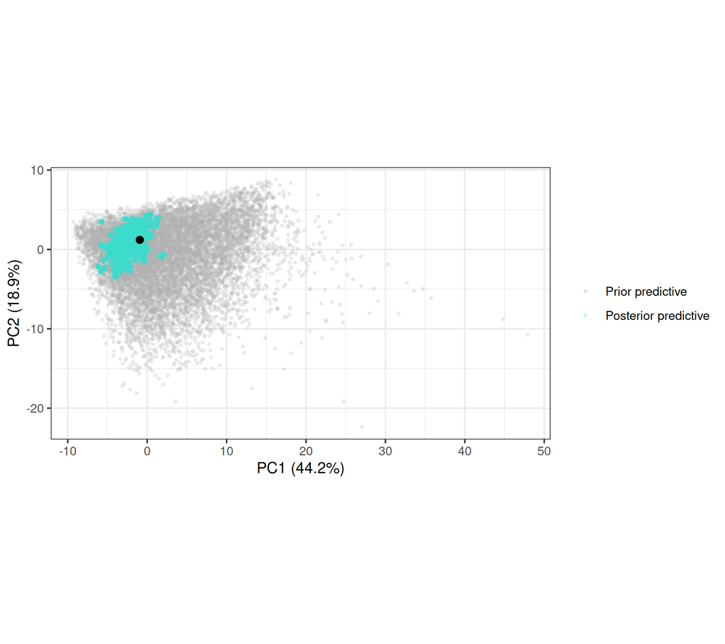

```r
print(plot_gof_pca)
```

- Does the observation fall among the posterior predictive simulations?
- Would that be enough to conclude that every statistic is well reproduced?

Before drawing a conclusion, look at how much variation the axes capture. The scree plot shows the contribution of each component.

```r
plot_gof_scree = ggplot(
  data.frame(
    component = seq_along(gof_pca_variance),
    percent = 100 * gof_pca_variance
  ),
  aes(x = component, y = percent)
) +
  geom_col(fill = "grey55", width = 0.85) +
  theme_bw() +
  labs(
    x = "Principal component",
    y = "Variance explained (%)"
  )
```

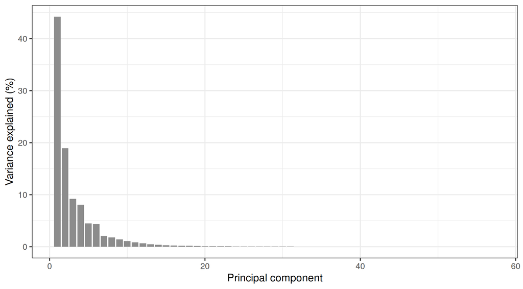

```r
print(plot_gof_scree)
```

- How much variation do PC1 and PC2 represent together?
- Could a mismatch appear on an axis we have not plotted?

**Check your answer**

An observation far from the posterior cloud suggests a mismatch in the combination of statistics represented by these axes.

An observation inside the cloud is reassuring for this projection, but it says nothing definite about the directions we have left out. A difference may still appear on a later component or in an individual statistic.

PCA finds the directions that vary most among simulations. Those are not necessarily the directions where the model fails most clearly.

We have now examined both model support and model fit. Let us finish by looking within the genome: which individual loci appear to resist gene flow?

## 10. Which loci resist gene flow?

Our results support recent gene flow that varies across the genome. Where might the less permeable regions be?

Think of loci close to reproductive barriers and loci that pass more freely between species. Real barriers differ in strength, and a sequenced locus may be tightly or only loosely linked to one.

We will use a simple comparison: a locus with migration versus a locus with zero migration.

We keep the fitted demographic background, including population sizes and the split and contact times. We then compare two alternatives for an individual locus:

- migration in both directions;
- no migration in either direction.

The simulations have already been prepared using the fitted DILS parameter distributions. This time, each simulated dataset represents one locus.

Our question is therefore about candidates for bidirectional barriers. We are not testing one-way barriers in this comparison.

### Explore the table

Read the monolocus reference table:

```r
barriers_ss = read.table(
  "data/locus_model_choice_data.tsv",
  header = TRUE
) %>%
  tibble::as_tibble()
```

Take a look at the rows before preparing the forest.

```r
barriers_ss
```

```
# A tibble: 21,157 × 29
   origin     fitted_model dataset_id locus_id true_class row_in_source bialsites_avg sf_avg sxA_avg sxB_avg  ss_avg successive_ss_avg piA_avg piB_avg
   <chr>      <chr>        <chr>      <chr>    <chr>              <int>         <int>  <dbl>   <dbl>   <dbl>   <dbl>             <int>   <dbl>   <dbl>
 1 training_… SC_2M_2N     training_… <NA>     migration              1            31      0 0.0198   0.0695 0.0645                  2 0.0371   0.0476
 2 training_… SC_2M_2N     training_… <NA>     migration              2            10      0 0.00496  0.0397 0.00496                 0 0.00529  0.0225
 3 training_… SC_2M_2N     training_… <NA>     migration              3            25      0 0.0298   0.0347 0.0596                  2 0.0354   0.0407
 4 training_… SC_2M_2N     training_… <NA>     migration              4            40      0 0.0347   0.129  0.0347                  1 0.0288   0.0771
 5 training_… SC_2M_2N     training_… <NA>     migration              5            21      0 0.0596   0.0298 0.0149                  1 0.0351   0.0149
 6 training_… SC_2M_2N     training_… <NA>     migration              6            43      0 0.0447   0.0893 0.0794                  2 0.0424   0.0771
 7 training_… SC_2M_2N     training_… <NA>     migration              7            33      0 0.0298   0.0645 0.0695                  4 0.0400   0.0457
 8 training_… SC_2M_2N     training_… <NA>     migration              8            28      0 0.0298   0.0298 0.0794                  6 0.0486   0.0493
 9 training_… SC_2M_2N     training_… <NA>     migration              9            18      0 0.0198   0.0298 0.0397                  2 0.0208   0.0334
10 training_… SC_2M_2N     training_… <NA>     migration             10            23      0 0.0198   0.0893 0.00496                 1 0.00926  0.0324
# ℹ 21,147 more rows
# ℹ 15 more variables: thetaA_avg <dbl>, thetaB_avg <dbl>, DtajA_avg <dbl>, DtajB_avg <dbl>, divAB_avg <dbl>, netdivAB_avg <dbl>, minDivAB_avg <dbl>,
#   maxDivAB_avg <dbl>, Gmin_avg <dbl>, Gmax_avg <dbl>, FST_avg <dbl>, ss_sf <int>, ss_noSf <int>, noSs_sf <int>, noSs_noSf <int>
```

Which columns describe the origin of a row, and which contain genetic statistics?

```r
names(barriers_ss)
```

```
 [1] "origin"            "fitted_model"      "dataset_id"        "locus_id"          "true_class"        "row_in_source"     "bialsites_avg"
 [8] "sf_avg"            "sxA_avg"           "sxB_avg"           "ss_avg"            "successive_ss_avg" "piA_avg"           "piB_avg"
[15] "thetaA_avg"        "thetaB_avg"        "DtajA_avg"         "DtajB_avg"         "divAB_avg"         "netdivAB_avg"      "minDivAB_avg"
[22] "maxDivAB_avg"      "Gmin_avg"          "Gmax_avg"          "FST_avg"           "ss_sf"             "ss_noSf"           "noSs_sf"
[29] "noSs_noSf"
```

How many simulated and observed loci are available?

```r
barriers_ss %>%
  dplyr::count(origin)
```

```
# A tibble: 3 × 2
  origin                 n
  <chr>              <int>
1 observed_locus      1157
2 training_isolation 10000
3 training_migration 10000
```

There are 10,000 simulations with migration, 10,000 without migration and 1,157 observed loci.

The first six columns describe the rows. `true_class` is known for simulations, while the observed loci are precisely the ones we want to classify.

The `_avg` suffixes come from the DILS column names. Here, each row describes one locus.

### Choose the statistics

We will use 14 statistics that do not require haplotype phase, meaning that we do not need to reconstruct which alleles at different sites occur together on the same chromosome.

Store their names:

```r
barrier_statistics = c(
  "bialsites_avg",
  "sf_avg",
  "sxA_avg",
  "sxB_avg",
  "ss_avg",
  "piA_avg",
  "piB_avg",
  "thetaA_avg",
  "thetaB_avg",
  "DtajA_avg",
  "DtajB_avg",
  "divAB_avg",
  "netdivAB_avg",
  "FST_avg"
)
```

Keep the observed rows, including their locus identifiers so that we can find them again later.

```r
barriers_observed = barriers_ss %>%
  dplyr::filter(origin == "observed_locus")
```

Prepare the training examples with their known classes.

```r
barriers_training = barriers_ss %>%
  dplyr::filter(
    origin %in% c("training_isolation", "training_migration")
  ) %>%
  dplyr::select(true_class, dplyr::all_of(barrier_statistics)) %>%
  dplyr::mutate(
    true_class = factor(
      true_class,
      levels = c("migration", "isolation")
    )
  )
```

Give the observed loci the same predictor columns.

```r
barriers_observed_predictors = barriers_observed %>%
  dplyr::select(dplyr::all_of(barrier_statistics))
```

### Train the forest

The method should now be familiar. We train a classification forest, but each example is an individual locus rather than a multilocus dataset.

```r
set.seed(20260915)
```

```r
barrier_forest = abcrf(
  true_class ~ .,
  data = as.data.frame(barriers_training),
  ntree = 500,
  paral = FALSE,
  ncores = 1
)
```

How well does it distinguish the two simulated histories?

```r
barrier_forest
```

```
Call:
 abcrf(formula = true_class ~ ., data = as.data.frame(barriers_training), ntree = 500, paral = FALSE, ncores = 1)
includes the axes of a preliminary LDA

Number of simulations: 20000
Out-of-bag prior error rate: 4.755%

Confusion matrix:
          migration isolation class.error
migration      9343       657      0.0657
isolation       294      9706      0.0294
```

- How often is a simulated migration locus classified as isolation?
- How often is an isolation locus classified as migration?

**Check your answer**

Read the error for each true class. Some loci simulated with migration will be mistaken for isolation, and some isolation loci will be mistaken for migration.

Keep those errors in mind: the allocations of observed loci will be candidates to investigate, not error-free identifications.

### Classify the observed loci

We can apply this one forest to all 1,157 observed loci. Each receives an allocation and an estimated probability for that allocation.

```r
set.seed(20260915)
```

Classify the observed loci:

```r
locus_specific_modComp = predict(
  barrier_forest,
  obs = as.data.frame(barriers_observed_predictors),
  training = as.data.frame(barriers_training),
  ntree = 500,
  paral = FALSE,
  ncores = 1
)
```

The returned object contains the predictions. Put them in a tibble alongside the locus identifiers, so that we can work with them easily.

```r
barrier_results = tibble(
  locus_id = barriers_observed$locus_id,
  model = as.character(locus_specific_modComp$allocation),
  proba = as.numeric(locus_specific_modComp$post.prob)
)
```

Look at a few loci. Are all their allocations supported equally strongly?

```r
head(barrier_results, 12)
```

```
# A tibble: 12 × 3
   locus_id             model     proba
   <chr>                <chr>     <dbl>
 1 Contig132__m_86      migration 0.834
 2 Contig14160__m_10309 migration 0.924
 3 Contig15694__m_11665 isolation 0.704
 4 Contig17494__m_13318 migration 1
 5 Contig1829__m_1261   migration 0.855
 6 Contig18323__m_14042 migration 0.953
 7 Contig18748__m_14419 migration 0.811
 8 Contig19074__m_14733 migration 0.832
 9 Contig19268__m_14915 migration 0.798
10 Contig19334__m_14971 migration 0.969
11 Contig19663__m_15260 migration 0.651
12 Contig20298__m_15821 isolation 0.809
```

`proba` always refers to the selected class. On a migration row, it is support for migration; on an isolation row, it is support for isolation.

### How many candidates?

How many loci fall into each group? Count the allocations and express them as percentages.

```r
barrier_counts = barrier_results %>%
  dplyr::count(model) %>%
  dplyr::mutate(
    percentage = 100 * n / sum(n)
  )
```

Look at the balance between the two groups:

```r
barrier_counts
```

```
# A tibble: 2 × 3
  model         n percentage
  <chr>     <int>      <dbl>
1 isolation   185       16.0
2 migration   972       84.0
```

What proportion of the studied loci are candidates for bidirectional barriers?

**Check your answer**

The isolation allocations are our candidates. They resemble simulations with zero migration more than simulations with migration under this fitted background.

The percentage describes the loci studied here, not a measured fraction of the whole genome. A candidate may be linked to a barrier without containing the causal variant itself.

### Relate allocations to the statistics

What makes these two groups look different genetically? Let us connect the allocations back to the statistics.

Join by `locus_id` so that every prediction remains associated with the correct locus.

```r
barrier_results_ss = barrier_results %>%
  dplyr::left_join(
    barriers_observed %>%
      dplyr::select(
        locus_id,
        dplyr::all_of(barrier_statistics)
      ),
    by = "locus_id"
  )
```

For each locus, calculate the average of the two within-population diversity values.

```r
barrier_results_ss = barrier_results_ss %>%
  dplyr::mutate(
    mean_pi = (piA_avg + piB_avg) / 2
  )
```

This averages diversity in A and B; it does not pool the two populations into one sample.

Plot this average against shared polymorphism, using the inferred class to colour the loci.

```r
plot_barrier_statistics = ggplot(
  barrier_results_ss, aes(x = mean_pi, y = ss_avg, colour = model)
) +
  geom_point(alpha = 0.45, size = 1.3) +
  scale_colour_manual(
    values = c(migration = "#1BA39C", isolation = "#E67E22"),
    breaks = c("migration", "isolation")
  ) +
  labs(
    x = "Mean nucleotide diversity across populations",
    y = "Shared polymorphisms",
    colour = "Selected locus model"
  ) +
  theme_bw()
```

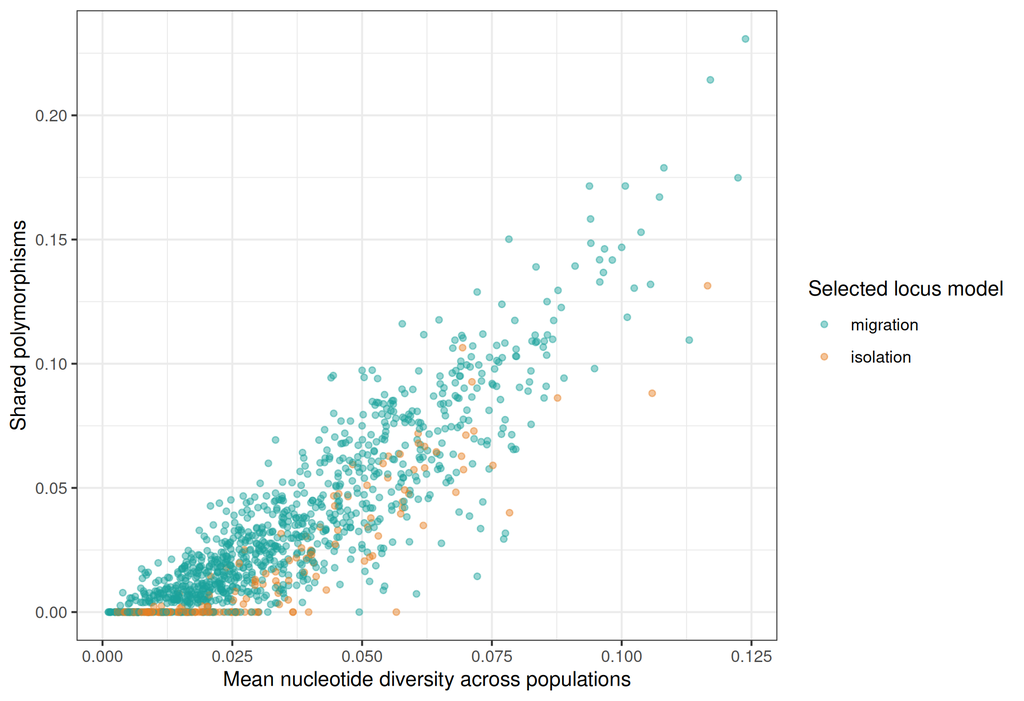

```r
print(plot_barrier_statistics)
```

- Do the two groups occupy different parts of the plot?
- Do they overlap?
- Can you recognise every candidate barrier locus from these two statistics alone?

**Check your answer**

You may see part of the distinction used by the forest, but remember that it combined 14 statistics. A two-statistic plot need not separate the allocations completely.

These statistics helped produce the classifications, so this is a way to understand the result rather than an independent test of it.

Save the table if you want to return to particular loci after the workshop.

```r
dir.create(
  "results/locus_model_choice",
  recursive = TRUE,
  showWarnings = FALSE
)
```

```r
readr::write_tsv(
  barrier_results_ss,
  "results/locus_model_choice/workshop_locus_results.tsv"
)
```

Try another pair of statistics, such as `FST_avg` and `netdivAB_avg`. Which patterns become easier to see?

We started by asking whether the species exchange genes, then explored when that exchange occurred, how demographic parameters vary, and whether the model reproduces the data. We have now identified individual loci that may be associated with reduced gene flow.

Those candidates are the beginning of a biological investigation: where are they in the genome, what do they do, and what other evidence might connect them to reproductive barriers?

Thank you for taking part, and congratulations on making it this far in the workshop!